# Using PLO(SC)²

This R-Markdown will guide you through an example analysis using PLO(SC)².

```r
library("Seurat")
library("PLOSC")
```

Reading in all files and automatically assigning sample names

```r
files <- Sys.glob("T:/scdata/covid_sc_cellranger/h5files/*.h5")
inputMatrices = readH5Files(files, sample_element=5, sample_processor=function(x){return(substr(x, 1, 10))})
```

```
[1] "20094_0001 T:/scdata/covid_sc_cellranger/h5files/20094_0001_A_B_raw_feature_bc_matrix.new.h5"
```

```
Genome matrix has multiple modalities, returning a list of matrices for this genome
```

```
[1] "WITH AB 20094_0001"
[1] "20094_0001 36601 x 6794880 genes x cells"
[1] "20094_0002 T:/scdata/covid_sc_cellranger/h5files/20094_0002_A_B_raw_feature_bc_matrix.new.h5"
```

```
Genome matrix has multiple modalities, returning a list of matrices for this genome
```

```
[1] "WITH AB 20094_0002"
[1] "20094_0002 36601 x 6794880 genes x cells"
[1] "20094_0003 T:/scdata/covid_sc_cellranger/h5files/20094_0003_A_B_raw_feature_bc_matrix.new.h5"
```

```
Genome matrix has multiple modalities, returning a list of matrices for this genome
```

```
[1] "WITH AB 20094_0003"
[1] "20094_0003 36601 x 6794880 genes x cells"
[1] "20094_0004 T:/scdata/covid_sc_cellranger/h5files/20094_0004_A_B_raw_feature_bc_matrix.new.h5"
```

```
Genome matrix has multiple modalities, returning a list of matrices for this genome
```

```
[1] "WITH AB 20094_0004"
[1] "20094_0004 36601 x 6794880 genes x cells"
[1] "20094_0005 T:/scdata/covid_sc_cellranger/h5files/20094_0005_A_B_raw_feature_bc_matrix.new.h5"
```

```
Genome matrix has multiple modalities, returning a list of matrices for this genome
```

```
[1] "WITH AB 20094_0005"
[1] "20094_0005 36601 x 6794880 genes x cells"
[1] "20094_0006 T:/scdata/covid_sc_cellranger/h5files/20094_0006_A_B_raw_feature_bc_matrix.new.h5"
```

```
Genome matrix has multiple modalities, returning a list of matrices for this genome
```

```
[1] "WITH AB 20094_0006"
[1] "20094_0006 36601 x 6794880 genes x cells"
[1] "20094_0007 T:/scdata/covid_sc_cellranger/h5files/20094_0007_A_B_raw_feature_bc_matrix.new.h5"
```

```
Genome matrix has multiple modalities, returning a list of matrices for this genome
```

```
[1] "WITH AB 20094_0007"
[1] "20094_0007 36601 x 6794880 genes x cells"
[1] "20094_0008 T:/scdata/covid_sc_cellranger/h5files/20094_0008_A_B_raw_feature_bc_matrix.new.h5"
```

```
Genome matrix has multiple modalities, returning a list of matrices for this genome
```

```
[1] "WITH AB 20094_0008"
[1] "20094_0008 36601 x 6794880 genes x cells"
[1] "20094_0009 T:/scdata/covid_sc_cellranger/h5files/20094_0009_A_B_raw_feature_bc_matrix.new.h5"
```

```
Genome matrix has multiple modalities, returning a list of matrices for this genome
```

```
[1] "WITH AB 20094_0009"
[1] "20094_0009 36601 x 6794880 genes x cells"
[1] "20094_0012 T:/scdata/covid_sc_cellranger/h5files/20094_0012_A_B_raw_feature_bc_matrix.new.h5"
```

```
Genome matrix has multiple modalities, returning a list of matrices for this genome
```

```
[1] "WITH AB 20094_0012"
[1] "20094_0012 36601 x 6794880 genes x cells"
```

Transforms the inputMatrices into Seurat objects, and preprocesses these for 3000 highly variable genes.

```r
objlist.raw = toObjList(inputMatrices, patternList_human(), 3000)
```

```
[1] "Renaming Cells"
[1] "Seurat obj project 20094_0001"
[1] "Got a total of mt-Genes: 13 MT-ND1, MT-ND2, MT-CO1, MT-CO2, MT-ATP8, MT-ATP6"
[1] "Got a total of Rpl-Genes: 54 RPL22, RPL11, RPL5, RPL31, RPL37A, RPL32"
[1] "Got a total of Rps-Genes: 49 RPS6KA1, RPS8, RPS27, RPS6KC1, RPS7, RPS27A"
[1] "Got a total of Rp-Genes: 103 RPL22, RPL11, RPS6KA1, RPS8, RPL5, RPS27"
[1] "20094_0001"
An object of class Seurat
36601 features across 6794880 samples within 1 assay
Active assay: RNA (36601 features, 3000 variable features)
 2 layers present: counts, data
[1] "Renaming Cells"
[1] "Seurat obj project 20094_0002"
[1] "Got a total of mt-Genes: 13 MT-ND1, MT-ND2, MT-CO1, MT-CO2, MT-ATP8, MT-ATP6"
[1] "Got a total of Rpl-Genes: 54 RPL22, RPL11, RPL5, RPL31, RPL37A, RPL32"
```

[output cut: 95 more lines]

The input matrices (in the example case these contain all cells) are filtered: 100 < nFeature_RNA < 6000, nCount_RNA > 500 and percent_mt < 7.

```r
objlist = scatterAndFilter(objlist.raw, nfeature_rna.lower=100, nfeature_rna.upper=6000, ncount_rna.lower=500, percent_mt.upper=7, plot=FALSE, plot.after=TRUE)
```

```
An object of class Seurat
36601 features across 2534 samples within 1 assay
Active assay: RNA (36601 features, 3000 variable features)
 2 layers present: counts, data
An object of class Seurat
36601 features across 2143 samples within 1 assay
Active assay: RNA (36601 features, 3000 variable features)
 2 layers present: counts, data
An object of class Seurat
36601 features across 1969 samples within 1 assay
Active assay: RNA (36601 features, 3000 variable features)
 2 layers present: counts, data
An object of class Seurat
36601 features across 884 samples within 1 assay
Active assay: RNA (36601 features, 3000 variable features)
```

[output cut: 185 more lines]

Number of remaining cells per experiment

```r
print("cells per experiment")
```

```
[1] "cells per experiment"
```

```r
print(mapply(sum, lapply(objlist, function(x) {dim(x)[2]})))
```

```
20094_0001 20094_0002 20094_0003 20094_0004 20094_0005 20094_0006 20094_0007 20094_0008 20094_0009 20094_0012
      2534       2143       1969        884       1202        198        490       1037        766       3449
```

```r
print("total cells")
```

```
[1] "total cells"
```

```r
print(sum(mapply(sum, lapply(objlist, function(x) {dim(x)[2]}))))
```

```
[1] 14672
```

The raw input files are not needed anymore and deleted to save some RAM.

```r
objlist.raw = NULL
inputMatrices = NULL
```

The different libraries are meant to be integrated/batch removed. This step is prepared here, by first estimating cell-cycle per cell, calculating 3000 highly variable features and regressing out the cell-cycle genes in 3000 scaled genes (which are also those used for the integrating the datasets.)

```r
finalList = prepareIntegration(objlist, cc.use.genes = cc.genes, nfeatures.variable = 3000, nfeatures.scale=3000, run.parallel=FALSE)
```

```
[1] "cells per experiment"
20094_0001 20094_0002 20094_0003 20094_0004 20094_0005 20094_0006 20094_0007 20094_0008 20094_0009 20094_0012
      2534       2143       1969        884       1202        198        490       1037        766       3449
[1] "total cells"
[1] 14672
[1] "Seurat obj project 20094_0001"
[1] "Seurat obj project 20094_0002"
[1] "Seurat obj project 20094_0003"
[1] "Seurat obj project 20094_0004"
[1] "Seurat obj project 20094_0005"
[1] "Seurat obj project 20094_0006"
[1] "Seurat obj project 20094_0007"
[1] "Seurat obj project 20094_0008"
[1] "Seurat obj project 20094_0009"
[1] "Seurat obj project 20094_0012"
[1] "SelectIntegrationFeatures"
[1] "Seurat obj project 20094_0001"
An object of class Seurat
36601 features across 2534 samples within 1 assay
Active assay: RNA (36601 features, 3000 variable features)
 2 layers present: counts, data
[1] "CellCycle 42 52"
```

```
Warning: The following features were not available: IGLV6-57, HAMP, UCHL1, NPIPB15, OLIG2, PDGFA, TRH, GATA2, IL22, LINC01644, AC009630.4, ATP5MC1, TNFSF15, AC106712.1, EGFL7, AL160408.3, LINC01825, IGHV1-69, TTC23, AC135050.3, IGLV4-69, TNS4, AC090409.1, MAP1S, HBG2, HSPA1B, CXCL14, FGF18, AC069368…
```

```
[1] "Seurat obj project 20094_0002"
An object of class Seurat
36601 features across 2143 samples within 1 assay
Active assay: RNA (36601 features, 3000 variable features)
 2 layers present: counts, data
[1] "CellCycle 42 52"
```

```
Warning: The following features were not available: MPZL2, NBL1, AC005614.1, TUBA3C, AC079209.1, AP002840.2, PTGFR, RBP4, PHACTR3, GALM, KRT8, TRAV16, LINC00960, ZNF404, AL157402.1, ZDHHC11, AC069234.5, AP000251.1, AC092809.2, HYDIN, ACOT11, CITED1, AC096564.1, NDUFV2, COL5A3, LINC02609, SH3RF3-AS1,…
```

```
[1] "Seurat obj project 20094_0003"
An object of class Seurat
36601 features across 1969 samples within 1 assay
Active assay: RNA (36601 features, 3000 variable features)
 2 layers present: counts, data
[1] "CellCycle 42 52"
```

```
Warning: The following features were not available: CLEC9A, SNX3, AR, CEP295NL, LINC02273, AC078881.1, AC005740.5, EML6, CCDC9B, MAP1LC3A, AL161891.1, ID2-AS1, CATIP, AL109809.5, INKA2, ZNF433, STEAP1B, MORF4L2-AS1, CDC42BPA, LINC01374, U47924.2, CABLES1, FLT3LG, CCDC126, MATN1, CLCN2, P3H2, PRRT3-A…
```

```
[1] "Seurat obj project 20094_0004"
An object of class Seurat
36601 features across 884 samples within 1 assay
Active assay: RNA (36601 features, 3000 variable features)
 2 layers present: counts, data
[1] "CellCycle 42 52"
```

```
Warning: The following features were not available: TRBV7-2, TRPC1, FGF2, SMIM1, BX284613.2, AC027682.4, PRMT7, PPP1R9A, ZNF713, NEFM, LONRF3, AC024361.1, GATA6, AC073320.1, FOXC1, P2RY2, AC110769.2, ZGLP1, GCNT4, CASC19, AC010173.1, PCBP3, TANC1, AL592071.1, ANXA4, FSTL3, TRIM6, ACE, GPR34, TSPAN18…
```

```
[1] "Seurat obj project 20094_0005"
An object of class Seurat
36601 features across 1202 samples within 1 assay
Active assay: RNA (36601 features, 3000 variable features)
 2 layers present: counts, data
[1] "CellCycle 42 52"
```

```
Warning: The following features were not available: EFNB2, FAM43A, AC244502.1, PDK1, GPRC5D, BIK, LINC02029, AC008378.1, AC016405.2, HIST1H2AB, TMEM121B, TRAV14DV4, TRAV38-2DV8, ZYG11A, HIST3H2BB, ENAH, AL118508.1, HAMP, IGHV4-39, AC092068.2, AL162741.1, GATA6, SIGLEC11, RTN2, AL356776.2, HOXA-AS2, …
```

```
[1] "Seurat obj project 20094_0006"
An object of class Seurat
36601 features across 198 samples within 1 assay
Active assay: RNA (36601 features, 3000 variable features)
 2 layers present: counts, data
[1] "CellCycle 42 52"
```

```
Warning: The following features were not available: CALM3, NUCKS1, CDKN2D, RPS26, HIST2H2AB, C1orf112, HIST1H2BL, PLK4, GNG2, CDK5RAP2, AC090152.1, APOBEC3C, MYEF2, FANCD2, RAD21, HMGA1P4, HDGF, AP004609.3, UBALD2, AC012360.3, BRD8, AC104596.1, AL031123.1, MPPED2, GABPB1, PBX4, MIS18BP1, AGBL5, MEF2…
```

```
[1] "Seurat obj project 20094_0007"
An object of class Seurat
36601 features across 490 samples within 1 assay
Active assay: RNA (36601 features, 3000 variable features)
 2 layers present: counts, data
[1] "CellCycle 42 52"
```

```
Warning: The following features were not available: MT-ATP8, RABAC1, EGR4, RHOBTB2, COMMD3, L3MBTL4, PCSK5, EPHB6, TRBV6-2, AC087893.2, TRAV25, IRF1, NUMBL, PGM2L1, GLB1L2, AC026304.1, AC243829.2, HMGN3-AS1, PAK3, TBC1D12, NETO2, ZNF618, RASSF8-AS1, AC139019.1, DNAJC3, FLVCR2, NCOA3, LIMK2, CARD6, A…
```

```
[1] "Seurat obj project 20094_0008"
An object of class Seurat
36601 features across 1037 samples within 1 assay
Active assay: RNA (36601 features, 3000 variable features)
 2 layers present: counts, data
[1] "CellCycle 42 52"
```

```
Warning: The following features were not available: B9D1, MSLN, IGHV3-20, IGHV2-26, ODC1, NDUFV2, TUBG1, LINC02762, SH3RF3-AS1, AC116651.1, CXCL11, CEACAM19, TIMM8B, ATP5MC1, ILF3-DT, S100A2, DOP1B, UCHL1, SNRPD1, AP001372.2, ALG14, SEL1L, GTSF1, ACTL6A, AL031668.2, ADSL, IGHV3-43, UQCC2, PRMT1, SLC…
```

```
[1] "Seurat obj project 20094_0009"
An object of class Seurat
36601 features across 766 samples within 1 assay
Active assay: RNA (36601 features, 3000 variable features)
 2 layers present: counts, data
[1] "CellCycle 42 52"
```

```
Warning: The following features were not available: MDM2, HCG18, TSIX, STK38L, SERPINB9, C17orf107, ZBP1, CXorf40B, NEDD9, LRRC8C-DT, GPR161, AC106795.2, ANGPT1, AP001059.1, NSMCE1-DT, LINC01588, PPP1R2C, ODF3L1, CDKL5, MFSD2A, IL4I1, WDR45B, B4GALT5, HGSNAT, CCDC9B, KBTBD11, ECHDC3, AC034238.1, MAC…
```

```
[1] "Seurat obj project 20094_0012"
An object of class Seurat
36601 features across 3449 samples within 1 assay
Active assay: RNA (36601 features, 3000 variable features)
 2 layers present: counts, data
[1] "CellCycle 42 52"
```

```
Warning: The following features were not available: DRD4, PF4V1, IGHV3-49, SCARA5, CLDN5, FIBCD1, MSRB3, CLEC1B, EPGN, AL365226.2, SRPX, CDH1, CCDC85A, IGLV2-23, TRAV1-1, SDR16C5, TREM2, MSLN, LINC01229, IGLV9-49, RPRM, AL139393.3, SH3D21, TRAV34, KIRREL3, LINC02381, MYZAP, SPATA18, AC133681.1, EDNR…
```

This step performs the actual integration using the features (genes) determined in the previous command, and using the rpca method. On some R installations running RunPCA in parallel stalls R, hence it can be switched off here. No further assay (e.g. CITE-seq) is to be integrated, hence add.do is set to False.

```r
integratedList_sample = performIntegration(finalList$data, "libintegration", features.integration = finalList$features, gex.method.normalization="LogNormalize", gex.method.integration="rpca", add.do=FALSE, run.parallel=TRUE)
```

```
$`20094_0001`
An object of class Seurat
36601 features across 2534 samples within 1 assay
Active assay: RNA (36601 features, 3000 variable features)
 3 layers present: counts, data, scale.data
 1 dimensional reduction calculated: pca

$`20094_0002`
An object of class Seurat
36601 features across 2143 samples within 1 assay
Active assay: RNA (36601 features, 3000 variable features)
 3 layers present: counts, data, scale.data
 1 dimensional reduction calculated: pca

$`20094_0003`
An object of class Seurat
36601 features across 1969 samples within 1 assay
Active assay: RNA (36601 features, 3000 variable features)
 3 layers present: counts, data, scale.data
 1 dimensional reduction calculated: pca

$`20094_0004`
An object of class Seurat
36601 features across 884 samples within 1 assay
Active assay: RNA (36601 features, 3000 variable features)
 3 layers present: counts, data, scale.data
 1 dimensional reduction calculated: pca

$`20094_0005`
An object of class Seurat
36601 features across 1202 samples within 1 assay
Active assay: RNA (36601 features, 3000 variable features)
 3 layers present: counts, data, scale.data
 1 dimensional reduction calculated: pca

$`20094_0006`
An object of class Seurat
36601 features across 198 samples within 1 assay
Active assay: RNA (36601 features, 3000 variable features)
 3 layers present: counts, data, scale.data
```

[output cut: 99 more lines]

```
 1 dimensional reduction calculated: pca

[1] "Current integration mode: rpca"
[1] "Object 20094_0001"
[1] "Object 20094_0002"
[1] "Object 20094_0003"
[1] "Object 20094_0004"
[1] "Object 20094_0005"
[1] "Object 20094_0006"
[1] "Object 20094_0007"
[1] "Object 20094_0008"
[1] "Object 20094_0009"
[1] "Object 20094_0012"
[1] "SelectIntegrationFeatures"
[1] "RunPCA on given features"
```

```
[1] "FindIntegrationAnchors"
```

```
Scaling features for provided objects
```

```
  |                                                  | 0 % ~calculating
  |+++++                                             | 10% ~03s
  |++++++++++                                        | 20% ~03s
  |+++++++++++++++                                   | 30% ~03s
  |++++++++++++++++++++                              | 40% ~02s
  |+++++++++++++++++++++++++                         | 50% ~01s
  |++++++++++++++++++++++++++++++                    | 60% ~01s
  |+++++++++++++++++++++++++++++++++++               | 70% ~01s
  |++++++++++++++++++++++++++++++++++++++++          | 80% ~01s
  |+++++++++++++++++++++++++++++++++++++++++++++     | 90% ~00s
  |++++++++++++++++++++++++++++++++++++++++++++++++++| 100% elapsed=03s
```

```
Computing within dataset neighborhoods
```

```
  |                                                  | 0 % ~calculating
  |+++++                                             | 10% ~05s
  |++++++++++                                        | 20% ~04s
  |+++++++++++++++                                   | 30% ~04s
  |++++++++++++++++++++                              | 40% ~03s
  |+++++++++++++++++++++++++                         | 50% ~02s
  |++++++++++++++++++++++++++++++                    | 60% ~02s
  |+++++++++++++++++++++++++++++++++++               | 70% ~01s
  |++++++++++++++++++++++++++++++++++++++++          | 80% ~01s
  |+++++++++++++++++++++++++++++++++++++++++++++     | 90% ~00s
  |++++++++++++++++++++++++++++++++++++++++++++++++++| 100% elapsed=04s
```

```
Finding all pairwise anchors
```

```
  |                                                  | 0 % ~calculating
```

```
Projecting new data onto SVD
Projecting new data onto SVD
Finding neighborhoods
Finding anchors
    Found 1160 anchors
```

```
  |++                                                | 2 % ~02m 37s
```

```
Projecting new data onto SVD
Projecting new data onto SVD
Finding neighborhoods
Finding anchors
    Found 834 anchors
```

```
  |+++                                               | 4 % ~02m 32s
```

```
Projecting new data onto SVD
Projecting new data onto SVD
Finding neighborhoods
Finding anchors
    Found 939 anchors
```

```
  |++++                                              | 7 % ~02m 28s
```

```
Projecting new data onto SVD
Projecting new data onto SVD
Finding neighborhoods
Finding anchors
    Found 662 anchors
```

```
  |+++++                                             | 9 % ~02m 20s
```

```
Projecting new data onto SVD
Projecting new data onto SVD
Finding neighborhoods
Finding anchors
    Found 706 anchors
```

```
  |++++++                                            | 11% ~02m 13s
```

```
Projecting new data onto SVD
Projecting new data onto SVD
Finding neighborhoods
Finding anchors
    Found 605 anchors
```

```
  |+++++++                                           | 13% ~02m 06s
```

```
Projecting new data onto SVD
Projecting new data onto SVD
Finding neighborhoods
Finding anchors
    Found 779 anchors
```

```
  |++++++++                                          | 16% ~02m 03s
```

```
Projecting new data onto SVD
Projecting new data onto SVD
Finding neighborhoods
Finding anchors
    Found 783 anchors
```

```
  |+++++++++                                         | 18% ~02m 00s
```

```
Projecting new data onto SVD
Projecting new data onto SVD
Finding neighborhoods
Finding anchors
    Found 627 anchors
```

```
  |++++++++++                                        | 20% ~01m 56s
```

```
Projecting new data onto SVD
Projecting new data onto SVD
Finding neighborhoods
Finding anchors
    Found 715 anchors
```

```
  |++++++++++++                                      | 22% ~01m 51s
```

```
Projecting new data onto SVD
Projecting new data onto SVD
Finding neighborhoods
Finding anchors
    Found 292 anchors
```

```
  |+++++++++++++                                     | 24% ~01m 46s
```

```
Projecting new data onto SVD
Projecting new data onto SVD
Finding neighborhoods
Finding anchors
    Found 333 anchors
```

```
  |++++++++++++++                                    | 27% ~01m 42s
```

```
Projecting new data onto SVD
Projecting new data onto SVD
Finding neighborhoods
Finding anchors
    Found 292 anchors
```

```
  |+++++++++++++++                                   | 29% ~01m 37s
```

```
Projecting new data onto SVD
Projecting new data onto SVD
Finding neighborhoods
Finding anchors
    Found 309 anchors
```

```
  |++++++++++++++++                                  | 31% ~01m 32s
```

```
Projecting new data onto SVD
Projecting new data onto SVD
Finding neighborhoods
Finding anchors
    Found 345 anchors
```

```
  |+++++++++++++++++                                 | 33% ~01m 27s
```

```
Projecting new data onto SVD
Projecting new data onto SVD
Finding neighborhoods
Finding anchors
    Found 456 anchors
```

```
  |++++++++++++++++++                                | 36% ~01m 24s
```

```
Projecting new data onto SVD
Projecting new data onto SVD
Finding neighborhoods
Finding anchors
    Found 497 anchors
```

```
  |+++++++++++++++++++                               | 38% ~01m 21s
```

```
Projecting new data onto SVD
Projecting new data onto SVD
Finding neighborhoods
Finding anchors
    Found 403 anchors
```

```
  |++++++++++++++++++++                              | 40% ~01m 18s
```

```
Projecting new data onto SVD
Projecting new data onto SVD
Finding neighborhoods
Finding anchors
    Found 401 anchors
```

```
  |++++++++++++++++++++++                            | 42% ~01m 14s
```

```
Projecting new data onto SVD
Projecting new data onto SVD
Finding neighborhoods
Finding anchors
    Found 488 anchors
```

```
  |+++++++++++++++++++++++                           | 44% ~01m 11s
```

```
Projecting new data onto SVD
Projecting new data onto SVD
Finding neighborhoods
Finding anchors
    Found 249 anchors
```

```
  |++++++++++++++++++++++++                          | 47% ~01m 07s
```

```
Projecting new data onto SVD
Projecting new data onto SVD
Finding neighborhoods
Finding anchors
    Found 623 anchors
```

```
  |+++++++++++++++++++++++++                         | 49% ~01m 04s
```

```
Projecting new data onto SVD
Projecting new data onto SVD
Finding neighborhoods
Finding anchors
    Found 737 anchors
```

```
  |++++++++++++++++++++++++++                        | 51% ~01m 02s
```

```
Projecting new data onto SVD
Projecting new data onto SVD
Finding neighborhoods
Finding anchors
    Found 603 anchors
```

```
  |+++++++++++++++++++++++++++                       | 53% ~59s
```

```
Projecting new data onto SVD
Projecting new data onto SVD
Finding neighborhoods
Finding anchors
    Found 570 anchors
```

```
  |++++++++++++++++++++++++++++                      | 56% ~56s
```

```
Projecting new data onto SVD
Projecting new data onto SVD
Finding neighborhoods
Finding anchors
    Found 618 anchors
```

```
  |+++++++++++++++++++++++++++++                     | 58% ~54s
```

```
Projecting new data onto SVD
Projecting new data onto SVD
Finding neighborhoods
Finding anchors
    Found 275 anchors
```

```
  |++++++++++++++++++++++++++++++                    | 60% ~50s
```

```
Projecting new data onto SVD
Projecting new data onto SVD
Finding neighborhoods
Finding anchors
    Found 444 anchors
```

```
  |++++++++++++++++++++++++++++++++                  | 62% ~47s
```

```
Projecting new data onto SVD
Projecting new data onto SVD
Finding neighborhoods
Finding anchors
    Found 643 anchors
```

```
  |+++++++++++++++++++++++++++++++++                 | 64% ~45s
```

```
Projecting new data onto SVD
Projecting new data onto SVD
Finding neighborhoods
Finding anchors
    Found 538 anchors
```

```
  |++++++++++++++++++++++++++++++++++                | 67% ~42s
```

```
Projecting new data onto SVD
Projecting new data onto SVD
Finding neighborhoods
Finding anchors
    Found 483 anchors
```

```
  |+++++++++++++++++++++++++++++++++++               | 69% ~39s
```

```
Projecting new data onto SVD
Projecting new data onto SVD
Finding neighborhoods
Finding anchors
    Found 452 anchors
```

```
  |++++++++++++++++++++++++++++++++++++              | 71% ~36s
```

```
Projecting new data onto SVD
Projecting new data onto SVD
Finding neighborhoods
Finding anchors
    Found 528 anchors
```

```
  |+++++++++++++++++++++++++++++++++++++             | 73% ~33s
```

```
Projecting new data onto SVD
Projecting new data onto SVD
Finding neighborhoods
Finding anchors
    Found 264 anchors
```

```
  |++++++++++++++++++++++++++++++++++++++            | 76% ~30s
```

```
Projecting new data onto SVD
Projecting new data onto SVD
Finding neighborhoods
Finding anchors
    Found 363 anchors
```

```
  |+++++++++++++++++++++++++++++++++++++++           | 78% ~27s
```

```
Projecting new data onto SVD
Projecting new data onto SVD
Finding neighborhoods
Finding anchors
    Found 524 anchors
```

```
  |++++++++++++++++++++++++++++++++++++++++          | 80% ~24s
```

```
Projecting new data onto SVD
Projecting new data onto SVD
Finding neighborhoods
Finding anchors
    Found 840 anchors
```

```
  |++++++++++++++++++++++++++++++++++++++++++        | 82% ~22s
```

```
Projecting new data onto SVD
Projecting new data onto SVD
Finding neighborhoods
Finding anchors
    Found 949 anchors
```

```
  |+++++++++++++++++++++++++++++++++++++++++++       | 84% ~20s
```

```
Projecting new data onto SVD
Projecting new data onto SVD
Finding neighborhoods
Finding anchors
    Found 711 anchors
```

```
  |++++++++++++++++++++++++++++++++++++++++++++      | 87% ~17s
```

```
Projecting new data onto SVD
Projecting new data onto SVD
Finding neighborhoods
Finding anchors
    Found 627 anchors
```

```
  |+++++++++++++++++++++++++++++++++++++++++++++     | 89% ~14s
```

```
Projecting new data onto SVD
Projecting new data onto SVD
Finding neighborhoods
Finding anchors
    Found 704 anchors
```

```
  |++++++++++++++++++++++++++++++++++++++++++++++    | 91% ~11s
```

```
Projecting new data onto SVD
Projecting new data onto SVD
Finding neighborhoods
Finding anchors
    Found 319 anchors
```

```
  |+++++++++++++++++++++++++++++++++++++++++++++++   | 93% ~09s
```

```
Projecting new data onto SVD
Projecting new data onto SVD
Finding neighborhoods
Finding anchors
    Found 408 anchors
```

```
  |++++++++++++++++++++++++++++++++++++++++++++++++  | 96% ~06s
```

```
Projecting new data onto SVD
Projecting new data onto SVD
Finding neighborhoods
Finding anchors
    Found 666 anchors
```

```
  |+++++++++++++++++++++++++++++++++++++++++++++++++ | 98% ~03s
```

```
Projecting new data onto SVD
Projecting new data onto SVD
Finding neighborhoods
Finding anchors
    Found 523 anchors
```

```
  |++++++++++++++++++++++++++++++++++++++++++++++++++| 100% elapsed=02m 12s
```

[output not shown]

```
[1] "IntegrateData"
[1] "GEX integration done"
```

```
PC_ 1
Positive:  LYZ, FCN1, AIF1, SERPINA1, MNDA, CST3, CD68, CD14, S100A8, IFI30
       S100A9, SPI1, LST1, CSTA, VCAN, MS4A6A, GRN, AC020656.1, CFP, TYMP
       CSF3R, CEBPD, CLEC7A, FCGRT, TNFAIP2, CTSS, SLC11A1, CYBB, CPVL, MPEG1
Negative:  CCL5, NKG7, SYNE2, CST7, GZMA, CTSW, GZMH, TRBC2, GZMM, CD247
       KLRD1, FGFBP2, GZMB, GNLY, IL32, PRF1, HOPX, ISG20, CD7, C12orf75
       RORA, TRBC1, IFITM1, ADGRG1, KLRK1, CD3E, LIME1, CD2, LCK, CD3D
PC_ 2
Positive:  CD79A, MS4A1, TNFRSF13C, HLA-DQA1, BANK1, RALGPS2, IGHM, LINC00926, IGHD, MEF2C
       HLA-DRA, BLK, AFF3, HLA-DQB1, CD74, LTB, HLA-DRB1, PAX5, ADAM28, VPREB3
       NIBAN3, CD83, IGKC, TCL1A, SWAP70, HLA-DOB, TCF4, CD79B, FCRL2, FCRLA
Negative:  NKG7, CST7, GZMA, CTSW, GNLY, S100A4, GZMB, SRGN, CCL5, FGFBP2
       PRF1, GZMM, KLRD1, GZMH, PFN1, CD247, ID2, IFITM2, HOPX, ANXA1
       CD7, TMSB4X, CCL4, ADGRG1, IFITM1, FCGR3A, SPON2, IL32, ACTB, KLRB1
PC_ 3
Positive:  TYMS, PCLAF, ZWINT, TK1, BIRC5, CLSPN, STMN1, RRM2, NUSAP1, PTMA
       MIF, TOP2A, ASPM, CDT1, TUBB, GINS2, MKI67, CDC45, HIST1H4C, CENPM
       RPS11, KIFC1, NPM1, CDK1, ANP32B, RPL23, TMSB10, CENPU, HIST1H3B, NASP
Negative:  NKAPL, FADS1, LINC02076, S100A9, A2M-AS1, S100A8, NEAT1, FOXO3, BTBD8, DTHD1
       DENND3, SLC2A3, ZEB2, RAB20, GNAQ, ZFAT, THBS1, S100A12, CD14, VCAN
       INPPL1, ADD3-AS1, NUMB, HAVCR2, LINC02384, TMEM176B, AL592295.5, CSF3R, FCAR, AC009318.1
PC_ 4
Positive:  IL7R, CD3D, CD3G, TRAC, CD3E, PCLAF, BCL11B, IL32, LINC00892, TK1
       ZWINT, MKI67, TYMS, NUSAP1, MAL, CENPU, CACNA1I, TRABD2A, TSHZ2, PCNA
       THEMIS, TOP2A, INPP4B, CDK1, NELL2, CTLA4, RCAN3, NCAPH, CD6, TCF7
Negative:  KLRF1, FCGR3A, IGFBP7, CHST2, SPON2, PRF1, PLAC8, CLIC3, GZMB, FCER1G
       TYROBP, GNLY, SH2D1B, FGFBP2, ZBTB16, S1PR5, LAT2, KLRB1, TXK, HIPK2
       PTGDR, IL2RB, AREG, LYN, CTBP2, KLRD1, LAIR2, CCL4, NCR1, TMIGD2
PC_ 5
Positive:  CD3D, CD3E, RPL23, CD3G, RPS11, TRAC, TMSB10, IL32, TMSB4X, MIF
       NPM1, IL7R, TRGC2, TRBC2, S100A4, LIME1, LDHB, CD8B, RPLP0, DUSP2
       CD8A, ANXA1, SSR4, CD5, SEC61G, JUNB, CD2, S100A10, CD84, CRIP1
Negative:  NKAPL, FOXM1, RRM2, PCLAF, TYMS, HIST1H1B, PCNA, MKI67, TOP2A, CDK1
       ASPM, XIST, FADS1, HAVCR2, CD38, TK1, NUSAP1, CLSPN, KIFC1, GTSE1
       ASF1B, CDC6, LRRCC1, ITGAX, PKMYT1, STMN1, SPC24, GINS2, KIF15, MCM3
Warning: The default method for RunUMAP has changed from calling Python UMAP via reticulate to the R-native UWOT using the cosine metric
To use Python UMAP via reticulate, set umap.method to 'umap-learn' and metric to 'correlation'
This message will be shown once per session13:55:09 UMAP embedding parameters a = 0.9922 b = 1.112
Using method 'umap'
```

```
[1] "libintegration/ig_dimplot 8 6"
[1] "Saving to file libintegration/ig_dimplot.png"
[1] "Saving to file libintegration/ig_dimplot.pdf"
[1] "Saving to file libintegration/ig_dimplot.svg"
[1] "Saving to file libintegration/ig_dimplot.data"
```

The ElbowPlot helps us to estimate how many PCs are needed for dimensional reduction (e.g. UMAP).

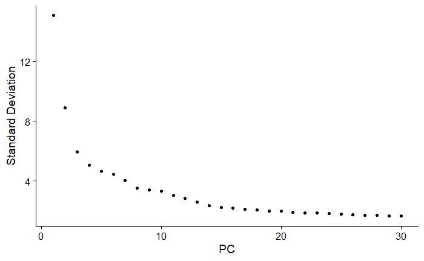

```r
ElbowPlot(integratedList_sample$integrated, ndims=30, reduction = "igpca")
```

The preprocessIntegrated function calculates a UMAP representation of the data and clusters the cells.

```r
obj.integrated = preprocessIntegrated(integratedList_sample$integrated, "integratedgex", "libintegration",  resolution=0.5, num.pcs=10, dim.reduction="igpca", with.hto=FALSE)
```

```
[1] "Scale Data"
[1] "dim.reduction igpca"
[1] "RunUMAP Data"
```

```
Using method 'umap'
```

```
[1] "FindNeighbors Data"
```

```
[1] "FindClusters Data"
Modularity Optimizer version 1.3.0 by Ludo Waltman and Nees Jan van Eck

Number of nodes: 14672
Number of edges: 495820

Running Louvain algorithm...
```

```
Maximum modularity in 10 random starts: 0.9184
Number of communities: 13
Elapsed time: 1 seconds
[1] "libintegration/dimplot_umap 12 8"
[1] "Saving to file libintegration/dimplot_umap.png"
[1] "Saving to file libintegration/dimplot_umap.pdf"
[1] "Saving to file libintegration/dimplot_umap.svg"
[1] "Saving to file libintegration/dimplot_umap.data"
[1] "libintegration/dimplot_umap_project 24 40"
[1] "Saving to file libintegration/dimplot_umap_project.png"
[1] "Saving to file libintegration/dimplot_umap_project.pdf"
[1] "Saving to file libintegration/dimplot_umap_project.svg"
[1] "Saving to file libintegration/dimplot_umap_project.data"
```

This removes the UMAP calculated during the performIntegration-step.

```r
obj.integrated@reductions$ig.umap = NULL
```

Showing the calculated UMAP representation.

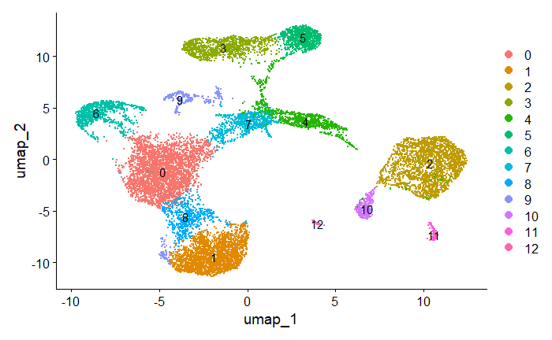

```r
DimPlot(obj.integrated, label=T)
```

```r
df = read.table("samples2condition.tsv", header = TRUE)
df[order(df$sampleid),]
```

|  | sampleid | library | patients | Mpoint | Condition |
| --- | --- | --- | --- | --- | --- |
| 1 | 1 | 20094_0001_A_B | 1-3 | 1 | SYMPTOMATIC |
| 4 | 2 | 20094_0002_A_B | 1-3 | 2 | SYMPTOMATIC |
| 7 | 3 | 20094_0003_A_B | 1-3 | 3 | SYMPTOMATIC |
| 2 | 4 | 20094_0004_A_B | 4-6 | 1 | ASYMPTOMATIC |
| 5 | 5 | 20094_0005_A_B | 4-6 | 2 | ASYMPTOMATIC |
| 8 | 6 | 20094_0006_A_B | 4-6 | 3 | ASYMPTOMATIC |
| 3 | 7 | 20094_0007_A_B | 7-9 | 1 | SYMPTOMATIC |
| 6 | 8 | 20094_0008_A_B | 7-9 | 2 | SYMPTOMATIC |
| 9 | 9 | 20094_0009_A_B | 7-9 | 3 | SYMPTOMATIC |
| 10 | 12 | 20094_0012_A_B | 12-14 | 1 | CONTROL |

```r
NA
```

We now add meta-data to our object for further processing.

```r
annotateList.sample_condition = list(
  list(name="SYMPTOMATIC", selector="^20094_0001"),
  list(name="SYMPTOMATIC", selector="^20094_0002"),
  list(name="SYMPTOMATIC", selector="^20094_0003"),
  list(name="ASYMPTOMATIC", selector="^20094_0004"),
  list(name="ASYMPTOMATIC", selector="^20094_0005"),
  list(name="ASYMPTOMATIC", selector="^20094_0006"),
  list(name="SYMPTOMATIC", selector="^20094_0007"),
  list(name="SYMPTOMATIC", selector="^20094_0008"),
  list(name="SYMPTOMATIC", selector="^20094_0009"),
  list(name="CONTROL", selector="^20094_0012")

)

obj.integrated = annotateByCellnamePattern( obj.integrated, "condition", annotateList.sample_condition, order=c("CONTROL", "ASYMPTOMATIC", "SYMPTOMATIC"))
```

```
[1] "SYMPTOMATIC TRUE"
[1] "SYMPTOMATIC TRUE"
[1] "SYMPTOMATIC TRUE"
[1] "ASYMPTOMATIC TRUE"
[1] "ASYMPTOMATIC TRUE"
[1] "ASYMPTOMATIC TRUE"
[1] "SYMPTOMATIC TRUE"
[1] "SYMPTOMATIC TRUE"
[1] "SYMPTOMATIC TRUE"
[1] "CONTROL TRUE"
[1] SYMPTOMATIC  ASYMPTOMATIC CONTROL
Levels: CONTROL ASYMPTOMATIC SYMPTOMATIC
```

```r
annotateList.sample_condition = list(
  list(name="TP 1", selector="^20094_0001"),
  list(name="TP 2", selector="^20094_0002"),
  list(name="TP 3", selector="^20094_0003"),
  list(name="TP 1", selector="^20094_0004"),
  list(name="TP 2", selector="^20094_0005"),
  list(name="TP 3", selector="^20094_0006"),
  list(name="TP 1", selector="^20094_0007"),
  list(name="TP 2", selector="^20094_0008"),
  list(name="TP 3", selector="^20094_0009"),
  list(name="Ctrl", selector="^20094_0012")
)

obj.integrated = annotateByCellnamePattern( obj.integrated, "tp", annotateList.sample_condition, order=c("Ctrl", "TP 1", "TP 2", "TP 3"))
```

```
[1] "TP 1 TRUE"
[1] "TP 2 TRUE"
[1] "TP 3 TRUE"
[1] "TP 1 TRUE"
[1] "TP 2 TRUE"
[1] "TP 3 TRUE"
[1] "TP 1 TRUE"
[1] "TP 2 TRUE"
[1] "TP 3 TRUE"
[1] "Ctrl TRUE"
[1] TP 1 TP 2 TP 3 Ctrl
Levels: Ctrl TP 1 TP 2 TP 3
```

The makeUMAPPlot functin draws a 2D UMAP array, which is a good tool to visualize a time-series experiment across several conditions.

```r
p=makeUMAPPlot(obj.integrated, dim1 = "condition", dim2="tp", group.by="idents", downsample = FALSE)
```

```
[1] CONTROL      ASYMPTOMATIC SYMPTOMATIC
Levels: CONTROL ASYMPTOMATIC SYMPTOMATIC
[1] Ctrl TP 1 TP 2 TP 3
Levels: Ctrl TP 1 TP 2 TP 3
[1] "CONTROL_Ctrl"
[1] 3449
[1] "CONTROL_TP 1"
[1] 0
[1] "CONTROL_TP 2"
[1] 0
[1] "CONTROL_TP 3"
[1] 0
[1] "ASYMPTOMATIC_Ctrl"
[1] 0
[1] "ASYMPTOMATIC_TP 1"
[1] 884
[1] "ASYMPTOMATIC_TP 2"
[1] 1202
[1] "ASYMPTOMATIC_TP 3"
[1] 198
[1] "SYMPTOMATIC_Ctrl"
[1] 0
[1] "SYMPTOMATIC_TP 1"
[1] 3024
[1] "SYMPTOMATIC_TP 2"
[1] 3180
[1] "SYMPTOMATIC_TP 3"
[1] 2735
[1] "Finishing Plot"
```

```
[1] "Combining Plots"
```

```
[1] "Combining Legend"
```

```
[1] "split_dimplot_downsample_no 24 20"
[1] "Saving to file split_dimplot_downsample_no.png"
[1] "Saving to file split_dimplot_downsample_no.pdf"
[1] "Saving to file split_dimplot_downsample_no.svg"
[1] "list case"
[1] "Saving to file split_dimplot_downsample_no.1.data"
[1] "Saving to file split_dimplot_downsample_no.2.data"
[1] "multi list case"
[1] "Saving to file split_dimplot_downsample_no.2.1.data data.frame"
[1] "Saving to file split_dimplot_downsample_no.2.2.data waiver"
[1] "Saving to file split_dimplot_downsample_no.2.3.data waiver"
[1] "Saving to file split_dimplot_downsample_no.2.4.data waiver"
[1] "Saving to file split_dimplot_downsample_no.2.5.data waiver"
[1] "Saving to file split_dimplot_downsample_no.2.6.data data.frame"
[1] "Saving to file split_dimplot_downsample_no.2.7.data data.frame"
[1] "Saving to file split_dimplot_downsample_no.2.8.data data.frame"
[1] "Saving to file split_dimplot_downsample_no.2.9.data waiver"
[1] "Saving to file split_dimplot_downsample_no.2.10.data data.frame"
[1] "Saving to file split_dimplot_downsample_no.2.11.data data.frame"
[1] "Saving to file split_dimplot_downsample_no.2.12.data data.frame"
```

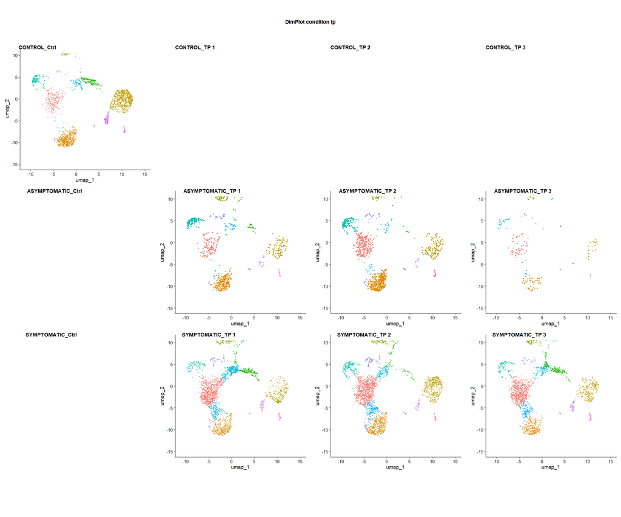

```r
save_plot(p, "split_dimplot_downsample_no", 24, 20)
```

The downsample-options reduces the number of shown cells in all plots to the same number (the minimum of all).

```r
p=makeUMAPPlot(obj.integrated, dim1 = "condition", dim2="tp", group.by="idents", downsample = TRUE)
```

```
[1] CONTROL      ASYMPTOMATIC SYMPTOMATIC
Levels: CONTROL ASYMPTOMATIC SYMPTOMATIC
[1] Ctrl TP 1 TP 2 TP 3
Levels: Ctrl TP 1 TP 2 TP 3
[1] "Downsampling 198"
[1] "CONTROL_Ctrl"
[1] 198
[1] "CONTROL_TP 1"
[1] 0
[1] "CONTROL_TP 2"
[1] 0
[1] "CONTROL_TP 3"
[1] 0
[1] "ASYMPTOMATIC_Ctrl"
[1] 0
[1] "ASYMPTOMATIC_TP 1"
[1] 198
[1] "ASYMPTOMATIC_TP 2"
[1] 198
[1] "ASYMPTOMATIC_TP 3"
[1] 198
[1] "SYMPTOMATIC_Ctrl"
[1] 0
[1] "SYMPTOMATIC_TP 1"
[1] 198
[1] "SYMPTOMATIC_TP 2"
[1] 198
[1] "SYMPTOMATIC_TP 3"
[1] 198
[1] "Finishing Plot"
```

```
[1] "Combining Plots"
```

```
[1] "Combining Legend"
```

```
[1] "split_dimplot_downsample 24 20"
[1] "Saving to file split_dimplot_downsample.png"
[1] "Saving to file split_dimplot_downsample.pdf"
[1] "Saving to file split_dimplot_downsample.svg"
[1] "list case"
[1] "Saving to file split_dimplot_downsample.1.data"
[1] "Saving to file split_dimplot_downsample.2.data"
[1] "multi list case"
[1] "Saving to file split_dimplot_downsample.2.1.data data.frame"
[1] "Saving to file split_dimplot_downsample.2.2.data waiver"
[1] "Saving to file split_dimplot_downsample.2.3.data waiver"
[1] "Saving to file split_dimplot_downsample.2.4.data waiver"
[1] "Saving to file split_dimplot_downsample.2.5.data waiver"
[1] "Saving to file split_dimplot_downsample.2.6.data data.frame"
[1] "Saving to file split_dimplot_downsample.2.7.data data.frame"
[1] "Saving to file split_dimplot_downsample.2.8.data data.frame"
[1] "Saving to file split_dimplot_downsample.2.9.data waiver"
[1] "Saving to file split_dimplot_downsample.2.10.data data.frame"
[1] "Saving to file split_dimplot_downsample.2.11.data data.frame"
[1] "Saving to file split_dimplot_downsample.2.12.data data.frame"
```

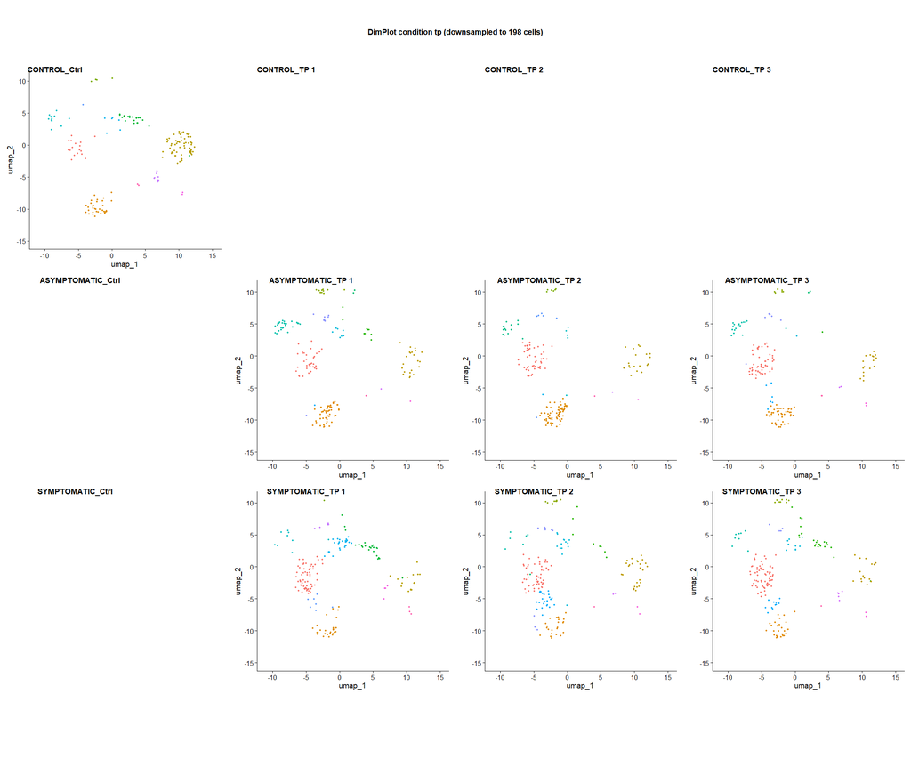

```r
save_plot(p, "split_dimplot_downsample", 24, 20)
```

Next we perform marker-gene analysis (DE genes per cluster). The makeDEResults function calls FindAllMarkers, but enhances these results with a summary statistic per gene.

```r
dir.create("libintegration/de")
exprdfTT = makeDEResults(obj.integrated, assay="RNA", test="t")
```

[output not shown]

[output cut: 1378 more lines]

```
Processed 18928 groups out of 25703. 74% done. Time elapsed: 5s. ETA: 1s.
Processed 25703 groups out of 25703. 100% done. Time elapsed: 5s. ETA: 0s.
[1] "11"

Processed 5297 groups out of 25734. 21% done. Time elapsed: 3s. ETA: 11s.
Processed 9452 groups out of 25734. 37% done. Time elapsed: 4s. ETA: 6s.
Processed 21246 groups out of 25734. 83% done. Time elapsed: 5s. ETA: 1s.
Processed 25734 groups out of 25734. 100% done. Time elapsed: 5s. ETA: 0s.
[1] "12"

Processed 5354 groups out of 25710. 21% done. Time elapsed: 3s. ETA: 11s.
Processed 9688 groups out of 25710. 38% done. Time elapsed: 4s. ETA: 6s.
Processed 22239 groups out of 25710. 86% done. Time elapsed: 5s. ETA: 0s.
Processed 25305 groups out of 25710. 98% done. Time elapsed: 6s. ETA: 0s.
Processed 25710 groups out of 25710. 100% done. Time elapsed: 6s. ETA: 0s.
```

```r
write.table(exprdfTT, "libintegration/de/expr_test_t.tsv", sep="\t", row.names=F, quote = F)
writexl::write_xlsx(exprdfTT, "libintegration/de/expr_test_t.xlsx")
print(head(exprdfTT))
```

|  | clusterID | gene | p_val | avg_log2FC | pct.1 | pct.2 | p_val_adj | num.cluster | min.cluster | lower_hinge.cluster | median.cluster | upper_hinge.cluster | max.cluster | mean.cluster | anum.cluster | num.bg | min.bg | lower_hinge.bg | median.bg | upper_hinge.bg | max.bg | mean.bg | anum.bg |
| --- | --- | --- | --- | --- | --- | --- | --- | --- | --- | --- | --- | --- | --- | --- | --- | --- | --- | --- | --- | --- | --- | --- | --- |
| 1 | 0 | A1BG | 4.835629e-13 | -0.6098250 | 0.086 | 0.155 | 1.769889e-08 | 296 | 0.5008935 | 0.9469305 | 1.0729594 | 1.304705 | 2.185927 | 1.1452831 | 3426 | 1738 | 0.1776767 | 0.6491045 | 0.8837890 | 1.131602 | 3.291546 | 0.9567623 | 11246 |
| 2 | 0 | A1BG-AS1 | 3.972522e-05 | -1.1728160 | 0.011 | 0.022 | 1.000000e+00 | 36 | 0.4470331 | 0.8520973 | 0.9521908 | 1.076266 | 1.452893 | 0.9677691 | 3426 | 251 | 0.2455944 | 0.5656087 | 0.7882174 | 1.022172 | 3.014546 | 0.8613934 | 11246 |
| 3 | 0 | A2M | 4.137226e-55 | 1.3912612 | 0.135 | 0.028 | 1.514266e-50 | 463 | 0.4470331 | 0.9370472 | 1.0452107 | 1.273458 | 2.919033 | 1.1405050 | 3426 | 315 | 0.2342526 | 0.9049838 | 1.0810588 | 1.497616 | 3.746660 | 1.3293314 | 11246 |
| 4 | 0 | A2M-AS1 | 1.393577e-153 | 1.7856856 | 0.316 | 0.066 | 5.100630e-149 | 1082 | 0.4470331 | 0.9796849 | 1.1158377 | 1.454401 | 3.388783 | 1.2386034 | 3426 | 745 | 0.2968594 | 0.9222418 | 1.1362482 | 1.603068 | 3.690441 | 1.3262082 | 11246 |
| 5 | 0 | AACS | 1.411290e-01 | 0.1842575 | 0.032 | 0.033 | 1.000000e+00 | 111 | 0.6089140 | 0.9231575 | 1.0497757 | 1.204008 | 2.705162 | 1.1076125 | 3426 | 370 | 0.1991868 | 0.5938594 | 0.8247512 | 1.081059 | 2.959148 | 0.9171271 | 11246 |
| 6 | 0 | AAK1 | 7.389180e-151 | 0.5741066 | 0.709 | 0.468 | 2.704514e-146 | 2429 | 0.5217806 | 1.1119891 | 1.4501391 | 1.752056 | 3.155804 | 1.4777797 | 3426 | 5260 | 0.1546643 | 0.9452726 | 1.2553284 | 1.731766 | 3.773983 | 1.3740540 | 11246 |

```r
NA
```

Next we calculate a module score for a set of interferon-stimulating genes, which are analysed in the following plots.

```r
DefaultAssay(obj.integrated)= "RNA"

isgGenes = unique(c("MT2A", "ISG15", "LY6E", "IFIT1", "IFIT2", "IFIT3", "IFITM1", "IFITM3", "IFI44L", "IFI6", "MX1", "IFI27",  "IFI44L", "RSAD2", "SIGLEC1", "IFIT1"))

obj.integrated = AddModuleScore(obj.integrated, features =  isgGenes, name = "isg_score_small")
```

Let’s briefly visualize the gene signature:

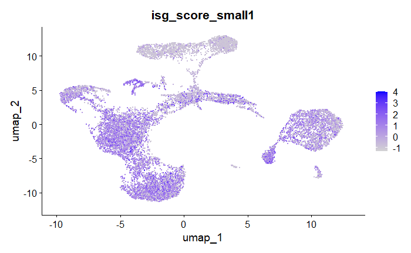

```r
FeaturePlot(obj.integrated, "isg_score_small1")
```

```r
obj.integrated$cond_tp = paste(obj.integrated$condition, obj.integrated$tp, sep=" ")
```

The splitFeaturePlot is a separate FeaturePlot for each panel defined by the split.by clause. All panels have the same limits and are thus easily comparable.

```r
p=splitFeaturePlot(obj.integrated, "isg_score_small1", split.by="cond_tp", title="FeaturePlot", ncol=4)
```

```
[1] "limits -1" "limits 1"
[1] "7"
[1] 1
```

```
[1] 2
```

```
[1] 3
```

```
[1] 4
```

```
[1] 5
```

```
[1] 6
```

```
[1] 7
```

```
[1] "ncol 4"
```

```
[1] "split_featureplot_isg 30 15"
[1] "Saving to file split_featureplot_isg.png"
[1] "Saving to file split_featureplot_isg.pdf"
[1] "Saving to file split_featureplot_isg.svg"
[1] "list case"
[1] "Saving to file split_featureplot_isg.1.data"
[1] "Saving to file split_featureplot_isg.2.data"
[1] "multi list case"
[1] "Saving to file split_featureplot_isg.2.1.data data.frame"
[1] "Saving to file split_featureplot_isg.2.2.data data.frame"
[1] "Saving to file split_featureplot_isg.2.3.data data.frame"
[1] "Saving to file split_featureplot_isg.2.4.data data.frame"
[1] "Saving to file split_featureplot_isg.2.5.data data.frame"
[1] "Saving to file split_featureplot_isg.2.6.data data.frame"
[1] "Saving to file split_featureplot_isg.2.7.data data.frame"
```

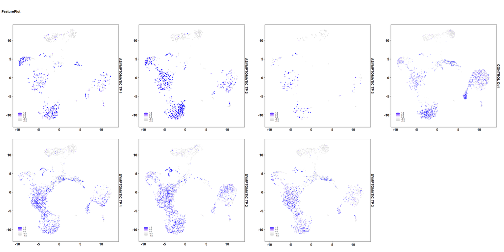

```r
save_plot(p, "split_featureplot_isg", 30, 15)
```

The comparativeVioBoxPlot combines a BoxPlot with a Violin Plot and performs statistical tests within each group (between the subsets defined by split.by).

```r
p=comparativeVioBoxPlot(obj.integrated, "isg_score_small1", group.by="condition", split.by="tp", yStepIncrease = 1, verbose=FALSE)
```

```
[1] "SYMPTOMATIC Ctrl 0"
[1] "Removing group SYMPTOMATIC"
[1] "ASYMPTOMATIC Ctrl 0"
[1] "Removing group ASYMPTOMATIC"
[1] "CONTROL TP 1 0"
[1] "CONTROL TP 2 0"
[1] "CONTROL TP 3 0"
[1] "Removing group CONTROL"
[1] "Existing Cells 14672"
[1] "New Cells 0"
[1] "SYMPTOMATIC 3"
[1] "ASYMPTOMATIC 3"
[1] "CONTROL 1"
[1] "TP 1 1.10543539557871"
[1] "TP 2 1.04267403662383"
[1] "TP 3 0.952347915061169"
[1] "Ctrl NA"
[1] "TP 1 1.03600907843311"
[1] "TP 2 1.10322999910783"
[1] "TP 3 1.00194124153661"
[1] "Ctrl NA"
[1] "TP 1 NA"
[1] "TP 2 NA"
[1] "TP 3 NA"
[1] "Ctrl 1.01263554921205"
[1] "Creating Plot"
```

```
[1] "comparative_violin_isg 12 8"
[1] "Saving to file comparative_violin_isg.png"
[1] "Saving to file comparative_violin_isg.pdf"
[1] "Saving to file comparative_violin_isg.svg"
[1] "Saving to file comparative_violin_isg.data"
```

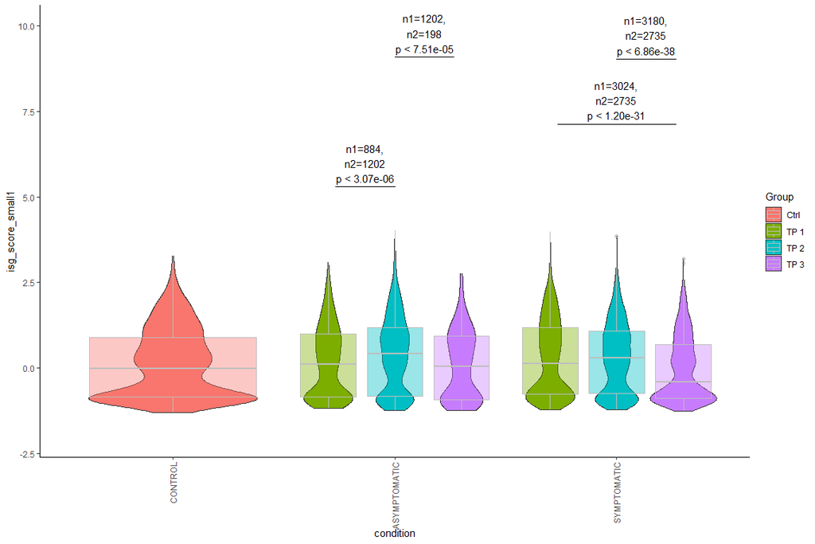

```r
save_plot(p, "comparative_violin_isg", 12, 8)
```

The plot is also customizable in terms of colors.

```r
dsrCols = list("Ctrl"="steelblue4", "TP 1"="darkred", "TP 2"="chocolate2", "TP 3"="darkseagreen3")

p=comparativeVioBoxPlot(obj.integrated, "isg_score_small1", group.by="condition", split.by="tp", yStepIncrease = 1, verbose=FALSE, dsrCols = dsrCols, boxplot_grey = "ivory4")
```

```
[1] "SYMPTOMATIC Ctrl 0"
[1] "Removing group SYMPTOMATIC"
[1] "ASYMPTOMATIC Ctrl 0"
[1] "Removing group ASYMPTOMATIC"
[1] "CONTROL TP 1 0"
[1] "CONTROL TP 2 0"
[1] "CONTROL TP 3 0"
[1] "Removing group CONTROL"
[1] "Existing Cells 14672"
[1] "New Cells 0"
[1] "SYMPTOMATIC 3"
[1] "ASYMPTOMATIC 3"
[1] "CONTROL 1"
[1] "TP 1 1.10543539557871"
[1] "TP 2 1.04267403662383"
[1] "TP 3 0.952347915061169"
[1] "Ctrl NA"
[1] "TP 1 1.03600907843311"
[1] "TP 2 1.10322999910783"
[1] "TP 3 1.00194124153661"
[1] "Ctrl NA"
[1] "TP 1 NA"
[1] "TP 2 NA"
[1] "TP 3 NA"
[1] "Ctrl 1.01263554921205"
[1] "Creating Plot"
[1] "TP 1" "TP 2" "TP 3" "Ctrl"
```

```
[1] "comparative_violin_isg_custom 12 8"
[1] "Saving to file comparative_violin_isg_custom.png"
[1] "Saving to file comparative_violin_isg_custom.pdf"
[1] "Saving to file comparative_violin_isg_custom.svg"
[1] "Saving to file comparative_violin_isg_custom.data"
```

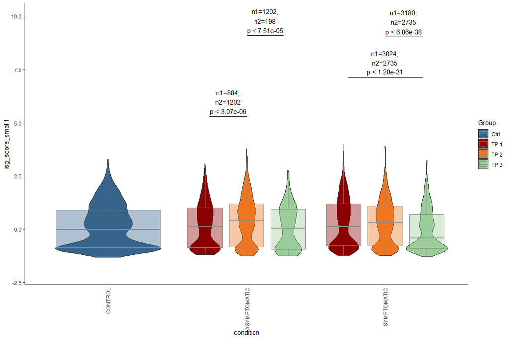

```r
save_plot(p, "comparative_violin_isg_custom", 12, 8)
```

```r
unique(obj.integrated$condition)
```

```
[1] SYMPTOMATIC  ASYMPTOMATIC CONTROL
Levels: CONTROL ASYMPTOMATIC SYMPTOMATIC
```

And also works when only one major group is available.

```
[1] "Existing Cells 2284"
[1] "New Cells 2284"
[1] "ASYMPTOMATIC 3"
[1] "TP 1 1.03600907843311"
[1] "TP 2 1.10322999910783"
[1] "TP 3 1.00194124153661"
[1] "Creating Plot"
[1] "TP 1" "TP 2" "TP 3"
```

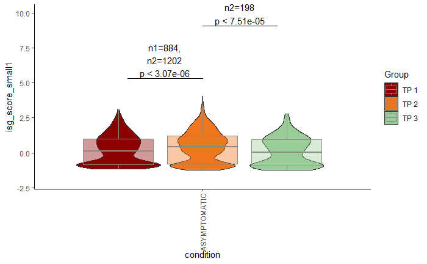

```r
dsrCols = list("Ctrl"="steelblue4", "TP 1"="darkred", "TP 2"="chocolate2", "TP 3"="darkseagreen3")

comparativeVioBoxPlot(subset(obj.integrated, condition=="ASYMPTOMATIC"), "isg_score_small1", group.by="condition", split.by="tp", yStepIncrease = 1, verbose=FALSE, dsrCols = dsrCols, boxplot_grey = "ivory4")
```

```r
obj.integrated = Seurat::ScaleData(obj.integrated)
```

```
Warning: Different features in new layer data than already exists for scale.data
```

```r
obj.integrated
```

```
An object of class Seurat
39601 features across 14672 samples within 2 assays
Active assay: RNA (36601 features, 3000 variable features)
 3 layers present: scale.data, data, counts
 1 other assay present: integratedgex
 2 dimensional reductions calculated: igpca, umap
```

```r
unique(obj.integrated$idents)
```

```
 [1] 7  10 0  9  2  3  1  4  5  8  11 6  12
Levels: 0 1 2 3 4 5 6 7 8 9 10 11 12
```

Single heatmap plot of the isgGenes per cluster. Scaled globally from ScaleData.

```r
plotGOIs = list("1"=list("clusters"=c("0"), "genes"=isgGenes))

p=enhancedHeatMap(obj.integrated, plotGOIs, group.by="idents", include_all_clusters = TRUE, title="Heatmap of ISG Genes", scale.by="GLOBAL")
```

```
[1] "Scaling data GLOBAL"
[1] "Fetching global scaled average expression"
```

```
As of Seurat v5, we recommend using AggregateExpression to perform pseudo-bulk analysis.First group.by variable `idents` starts with a number, appending `g` to ensure valid variable names
```

```
[1] "combined_lists"
[1] "0"
 [1] "MT2A"    "ISG15"   "LY6E"    "IFIT1"   "IFIT2"   "IFIT3"   "IFITM1"  "IFITM3"  "IFI44L"  "IFI6"    "MX1"     "IFI27"
[13] "RSAD2"   "SIGLEC1"
[1] "Clusters Missing"
character(0)
[1] "Genes Missing"
character(0)
[1] "Adding missing clusters"
 [1] "1"  "2"  "3"  "4"  "5"  "6"  "7"  "8"  "9"  "10" "11" "12"
```

```
[1] "heatmap_isg_genes 12 8"
[1] "Saving to file heatmap_isg_genes.png"
[1] "Saving to file heatmap_isg_genes.pdf"
[1] "Saving to file heatmap_isg_genes.svg"
```

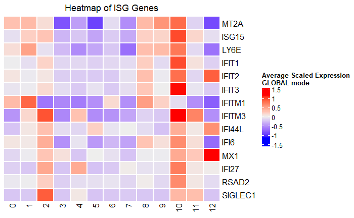

```r
save_plot(p, "heatmap_isg_genes", 12, 8, save.data = FALSE)
```

Single heatmap plot of the isgGenes per cluster. Scaled by all shown values in the heatmap.

```r
plotGOIs = list("1"=list("clusters"=c("0"), "genes"=isgGenes))

p=enhancedHeatMap(obj.integrated, plotGOIs, group.by="idents", include_all_clusters = TRUE, title="Heatmap of ISG Genes", scale.by="ALL")
```

```
[1] "Scaling data ALL"
[1] "Fetching average expression"
[1] "combined_lists"
[1] "0"
 [1] "MT2A"    "ISG15"   "LY6E"    "IFIT1"   "IFIT2"   "IFIT3"   "IFITM1"  "IFITM3"  "IFI44L"  "IFI6"    "MX1"     "IFI27"
[13] "RSAD2"   "SIGLEC1"
[1] "Clusters Missing"
character(0)
[1] "Genes Missing"
character(0)
[1] "Adding missing clusters"
 [1] "1"  "2"  "3"  "4"  "5"  "6"  "7"  "8"  "9"  "10" "11" "12"
```

```
[1] "heatmap_isg_genes_ALL 12 8"
[1] "Saving to file heatmap_isg_genes_ALL.png"
[1] "Saving to file heatmap_isg_genes_ALL.pdf"
[1] "Saving to file heatmap_isg_genes_ALL.svg"
```

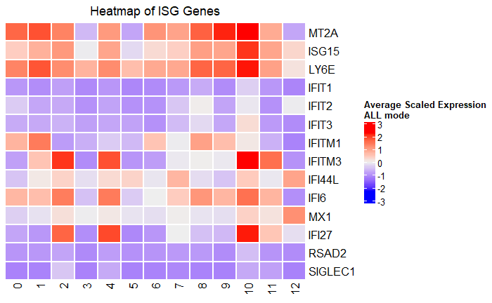

```r
save_plot(p, "heatmap_isg_genes_ALL", 12, 8, save.data = FALSE)
```

Split heatmap plot, grouping the cells per cluster and split the results per condition. Scaled globally from ScaleData

```r
p=makeComplexExprHeatmapSplit(obj.integrated, plotGOIs, group.by="idents", split.by="condition", include_all_clusters = TRUE, title="Heatmap of ISG Genes", scale.by="GLOBAL")
```

```
Scaling data GLOBAL[1] "0"
 [1] "MT2A"    "ISG15"   "LY6E"    "IFIT1"   "IFIT2"   "IFIT3"   "IFITM1"  "IFITM3"  "IFI44L"  "IFI6"    "MX1"     "IFI27"
[13] "RSAD2"   "SIGLEC1"
[1] "Fetching global scaled average expression"
[1] "Clusters Missing"
character(0)
[1] "Genes Missing"
character(0)
[1] "Adding missing clusters"
 [1] "1"  "2"  "3"  "4"  "5"  "6"  "7"  "8"  "9"  "10" "11" "12"
[1] "Removing clusters because they're not represented in subset"
character(0)
[1] "Fetching global scaled average expression"
[1] "Clusters Missing"
character(0)
[1] "Genes Missing"
character(0)
[1] "Adding missing clusters"
 [1] "1"  "2"  "3"  "4"  "5"  "6"  "7"  "8"  "9"  "10" "11" "12"
[1] "Removing clusters because they're not represented in subset"
character(0)
[1] "Fetching global scaled average expression"
[1] "Clusters Missing"
character(0)
[1] "Genes Missing"
character(0)
[1] "Adding missing clusters"
 [1] "1"  "2"  "3"  "4"  "5"  "6"  "7"  "8"  "9"  "10" "11" "12"
[1] "Removing clusters because they're not represented in subset"
character(0)
```

```
[1] "heatmap_split_isg_genes 30 10"
[1] "Saving to file heatmap_split_isg_genes.png"
[1] "Saving to file heatmap_split_isg_genes.pdf"
[1] "Saving to file heatmap_split_isg_genes.svg"
```

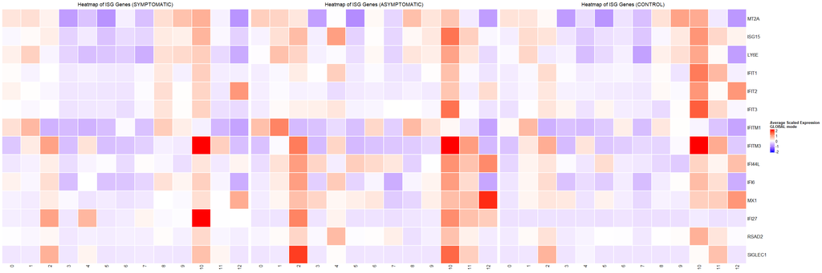

```r
save_plot(p, "heatmap_split_isg_genes", 30, 10, save.data = FALSE)
```

Split heatmap plot, grouping the cells per cluster and split the results per condition. Scaled by all shown values (over all 3 groups).

```r
p=makeComplexExprHeatmapSplit(obj.integrated, plotGOIs, group.by="idents", split.by="condition", include_all_clusters = TRUE, title="Heatmap of ISG Genes", scale.by="ALL")
```

```
Scaling data ALL[1] "0"
 [1] "MT2A"    "ISG15"   "LY6E"    "IFIT1"   "IFIT2"   "IFIT3"   "IFITM1"  "IFITM3"  "IFI44L"  "IFI6"    "MX1"     "IFI27"
[13] "RSAD2"   "SIGLEC1"
[1] "Fetching average expression"
[1] "Clusters Missing"
character(0)
[1] "Genes Missing"
character(0)
[1] "Adding missing clusters"
 [1] "1"  "2"  "3"  "4"  "5"  "6"  "7"  "8"  "9"  "10" "11" "12"
[1] "Removing clusters because they're not represented in subset"
character(0)
[1] "Fetching average expression"
[1] "Clusters Missing"
character(0)
[1] "Genes Missing"
character(0)
[1] "Adding missing clusters"
 [1] "1"  "2"  "3"  "4"  "5"  "6"  "7"  "8"  "9"  "10" "11" "12"
[1] "Removing clusters because they're not represented in subset"
character(0)
[1] "Fetching average expression"
[1] "Clusters Missing"
character(0)
[1] "Genes Missing"
character(0)
[1] "Adding missing clusters"
 [1] "1"  "2"  "3"  "4"  "5"  "6"  "7"  "8"  "9"  "10" "11" "12"
[1] "Removing clusters because they're not represented in subset"
character(0)
                 0          1           2          3          4           5           6           7           8           9
MT2A     1.5845688  1.8084085  1.36665425 -0.4836524  0.9755133 -0.63852114  1.09986631  0.96663164  1.65113403  2.14224193
ISG15    0.5109032  0.5643997  0.90042626 -0.1536394  1.0155712 -0.33832124 -0.04326024  0.46713720  1.03512290  0.92915313
LY6E     1.3854609  1.7319768  1.11636673  0.6241664  1.2236696  0.47727165  0.56719537  0.90444871  1.65060207  1.66519899
IFIT1   -0.8086132 -0.9536971 -0.90748525 -1.0373155 -0.8624689 -1.02847551 -1.02908449 -0.78882439 -0.62260077 -0.98522655
IFIT2   -0.1854094 -0.5714232 -0.82323144 -0.9402467 -0.7371689 -0.87821695 -0.92047507 -0.26428474  0.10591485 -0.64654757
IFIT3   -0.5693170 -0.6635954 -0.75608946 -0.9448991 -0.6462903 -0.87336952 -1.03199714 -0.46239034 -0.14562264 -0.66523492
IFITM1   0.7323646  1.2007204 -0.78706422 -0.6392194 -0.3902723 -0.55690191  0.21810815 -0.02411148  0.97696485  0.54195463
IFITM3  -0.7213139  0.6549316  2.07982926 -0.9347063  1.9565590 -0.89435796 -0.80573899 -0.06969285  0.08296923  0.03943282
IFI44L  -0.3344148 -0.1218814  0.13580177 -0.4971084  0.4002205 -0.01625344 -0.50811131  0.74020042 -0.11155180 -0.50166869
```

[output cut: 65 more lines]

```
                10          11            12
MT2A     2.3439162  0.76128616 -0.7639469462
ISG15    1.9676307  1.28790966  0.6841275357
LY6E     2.3029106  1.18316630 -0.0968549527
IFIT1   -0.1057604 -0.46457037 -1.0144851896
IFIT2    0.1193812 -0.72205546  0.0007496365
IFIT3    0.5272748 -0.43104020 -0.8668990384
IFITM1   0.1359582 -0.55082229 -1.0459140554
IFITM3   3.6472985  1.66469560 -0.7702926673
IFI44L   0.4349847  0.06633269  0.7700575648
IFI6     1.4822805  1.14977638 -0.8972987694
MX1      0.4428175  0.48411737  1.0008757031
IFI27   -0.3743213 -1.03552483 -1.0001578666
RSAD2   -0.3673840 -0.73075197 -0.9002062626
SIGLEC1 -0.9044765 -0.58100446 -1.0635026055
```

```
[1] "heatmap_split_isg_genes_ALL 30 10"
[1] "Saving to file heatmap_split_isg_genes_ALL.png"
[1] "Saving to file heatmap_split_isg_genes_ALL.pdf"
[1] "Saving to file heatmap_split_isg_genes_ALL.svg"
```

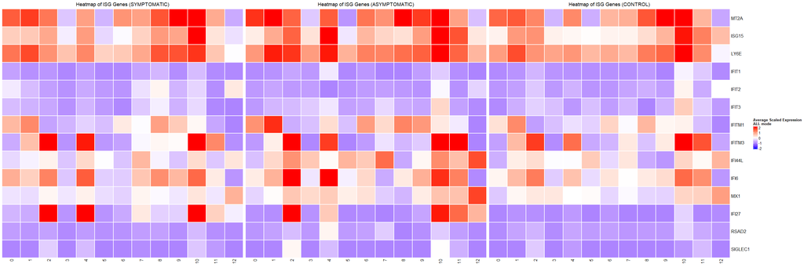

```r
save_plot(p, "heatmap_split_isg_genes_ALL", 30, 10, save.data = FALSE)
```

Split heatmap plot, grouping the cells per cluster and split the results per condition. Scaled per group/heatmap.

```r
p=makeComplexExprHeatmapSplit(obj.integrated, plotGOIs, group.by="idents", split.by="condition", include_all_clusters = TRUE, title="Heatmap of ISG Genes", scale.by="GROUP")
```

```
Scaling data GROUP[1] "0"
 [1] "MT2A"    "ISG15"   "LY6E"    "IFIT1"   "IFIT2"   "IFIT3"   "IFITM1"  "IFITM3"  "IFI44L"  "IFI6"    "MX1"     "IFI27"
[13] "RSAD2"   "SIGLEC1"
[1] "Fetching average expression"
[1] "Clusters Missing"
character(0)
[1] "Genes Missing"
character(0)
[1] "Adding missing clusters"
 [1] "1"  "2"  "3"  "4"  "5"  "6"  "7"  "8"  "9"  "10" "11" "12"
[1] "Removing clusters because they're not represented in subset"
character(0)
[1] "Fetching average expression"
[1] "Clusters Missing"
character(0)
[1] "Genes Missing"
character(0)
[1] "Adding missing clusters"
 [1] "1"  "2"  "3"  "4"  "5"  "6"  "7"  "8"  "9"  "10" "11" "12"
[1] "Removing clusters because they're not represented in subset"
character(0)
[1] "Fetching average expression"
[1] "Clusters Missing"
character(0)
[1] "Genes Missing"
character(0)
[1] "Adding missing clusters"
 [1] "1"  "2"  "3"  "4"  "5"  "6"  "7"  "8"  "9"  "10" "11" "12"
[1] "Removing clusters because they're not represented in subset"
character(0)
```

```
[1] "heatmap_split_isg_genes_GROUP 30 10"
[1] "Saving to file heatmap_split_isg_genes_GROUP.png"
[1] "Saving to file heatmap_split_isg_genes_GROUP.pdf"
[1] "Saving to file heatmap_split_isg_genes_GROUP.svg"
```

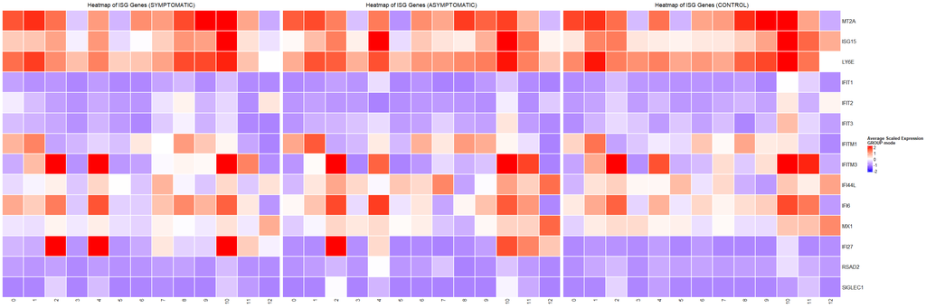

```r
save_plot(p, "heatmap_split_isg_genes_GROUP", 30, 10, save.data = FALSE)
```

This prepares the layout for the enhancedDotPlot. Per panel one entry in the plot elems with selected cells and a label is required.

```r
cells.control = cellIDForClusters(obj.integrated, "condition", c("CONTROL"))
cells.symptomatic = cellIDForClusters(obj.integrated, "condition", c("SYMPTOMATIC"))
cells.asymptomatic = cellIDForClusters(obj.integrated, "condition", c("ASYMPTOMATIC"))

plotElems = list()
plotElems[["Control"]] = list(cells=intersect(cells.control, cells.control), label="Control")
plotElems[["Symptomatic"]] = list(cells=intersect(cells.symptomatic,cells.symptomatic), label="Symptomatic")
plotElems[["Asymptomatic"]] = list(cells=intersect(cells.asymptomatic,cells.asymptomatic), label="Asymptomatic")
```

enhancedDotPlot of isg genes, scaled per all shown values.

```r
p=enhancedDotPlot(obj.integrated, plotElems, featureGenes = isgGenes, group.by="idents", title="DotPlot of ISG Genes", scale.by="ALL", rotate.x = T)
```

```
[1] "SCALING BY ALL"
[1] "Final plot checks"
[1] "Preparing Legend"
[1] "Preparing plot"
```

```
[1] "edotplot_split_isg_genes_ALL 30 10"
[1] "Saving to file edotplot_split_isg_genes_ALL.png"
[1] "Saving to file edotplot_split_isg_genes_ALL.pdf"
[1] "Saving to file edotplot_split_isg_genes_ALL.svg"
```

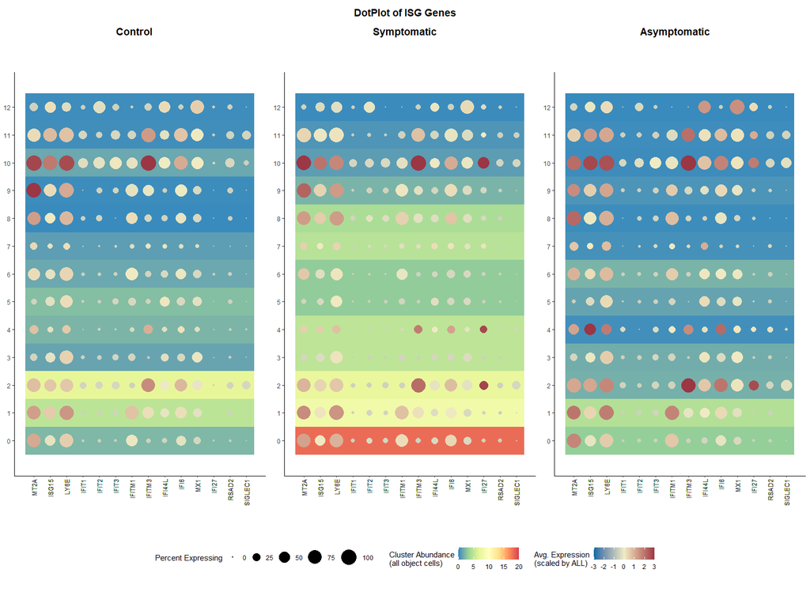

```r
save_plot(p, "edotplot_split_isg_genes_ALL", 30, 10, save.data = FALSE)
```

enhancedDotPlot of isg genes, scaled globally (from ScaleData).

```r
p=enhancedDotPlot(obj.integrated, plotElems, featureGenes = isgGenes, group.by="idents", title="DotPlot of ISG Genes", scale.by="GLOBAL", rotate.x = T)
```

```
[1] "SCALING BY GLOBAL"
[1] "Final plot checks"
[1] "Preparing Legend"
[1] "Preparing plot"
```

```
[1] "edotplot_split_isg_genes_GLOBAL 30 10"
[1] "Saving to file edotplot_split_isg_genes_GLOBAL.png"
[1] "Saving to file edotplot_split_isg_genes_GLOBAL.pdf"
[1] "Saving to file edotplot_split_isg_genes_GLOBAL.svg"
```

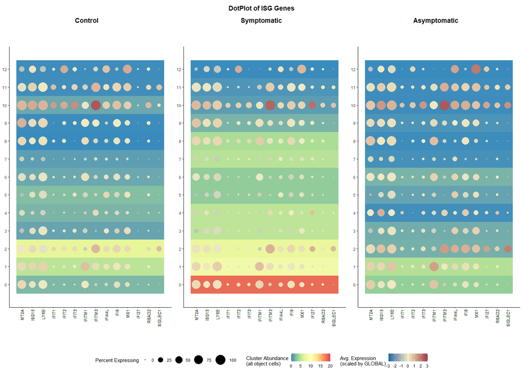

```r
save_plot(p, "edotplot_split_isg_genes_GLOBAL", 30, 10, save.data = FALSE)
```

enhancedDotPlot of isg genes, scaled per shown group.

```r
p=enhancedDotPlot(obj.integrated, plotElems, featureGenes = isgGenes, group.by="idents", title="DotPlot of ISG Genes", scale.by="GROUP",rotate.x = T)
```

```
[1] "SCALING BY GROUP"
[1] "Final plot checks"
[1] "Preparing Legend"
[1] "Preparing plot"
```

```
[1] "edotplot_split_isg_genes_GROUP 30 10"
[1] "Saving to file edotplot_split_isg_genes_GROUP.png"
[1] "Saving to file edotplot_split_isg_genes_GROUP.pdf"
[1] "Saving to file edotplot_split_isg_genes_GROUP.svg"
```

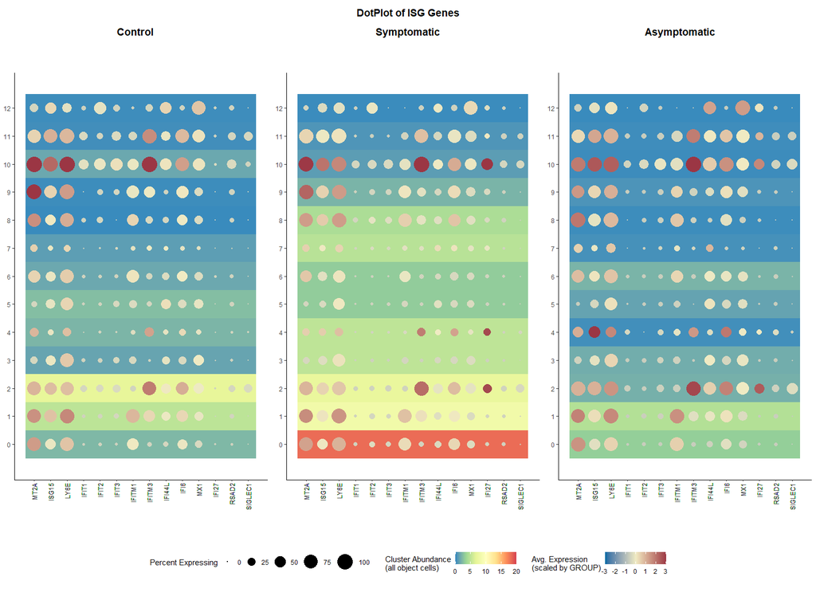

```r
save_plot(p, "edotplot_split_isg_genes_GROUP", 30, 10, save.data = FALSE)
```

enhancedDotPlot of isg genes, scaled per feature (across all 3 shown groups).

```r
p=enhancedDotPlot(obj.integrated, plotElems, featureGenes = isgGenes, group.by="idents", title="DotPlot of ISG Genes", scale.by="FEATURE", rotate.x=TRUE)
```

```
[1] "SCALING BY FEATURE"
[1] "Final plot checks"
[1] "Preparing Legend"
[1] "Preparing plot"
```

```
[1] "edotplot_split_isg_genes_FEATURE 30 10"
[1] "Saving to file edotplot_split_isg_genes_FEATURE.png"
[1] "Saving to file edotplot_split_isg_genes_FEATURE.pdf"
[1] "Saving to file edotplot_split_isg_genes_FEATURE.svg"
```

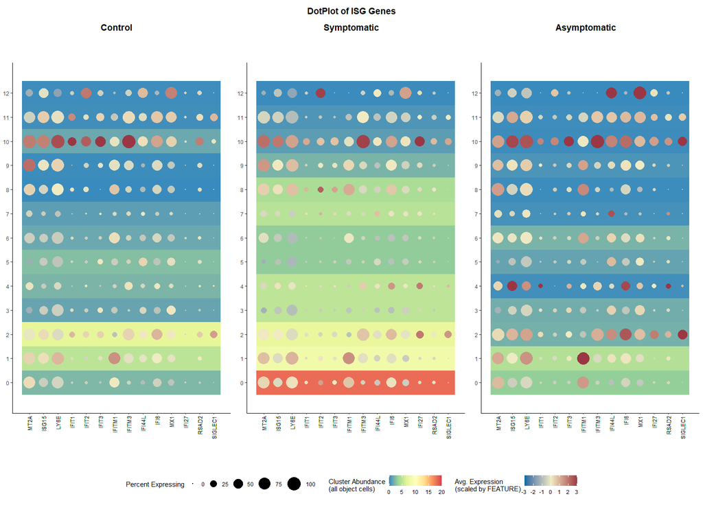

```r
save_plot(p, "edotplot_split_isg_genes_FEATURE", 30, 10, save.data = FALSE)
```

Compare symptomatic vs asymptomatic in all clusters (at TP1).

```r
cells.tp1 = cellIDForClusters(obj.integrated, "tp", c("TP 1"))

comparison.sympt_asympt = compareCellsByCluster(obj.integrated, intersect(cells.symptomatic, cells.tp1), intersect(cells.asymptomatic, cells.tp1), "symptomatic", "asymptomatic", outfolder="./de", group.by="idents", heatmap.plot=TRUE)
```

[output not shown]

[output cut: 51 more lines]

[output not shown]

```
./de/cluster_0.symptomatic_asymptomatic.tsv
./de/cluster_0.symptomatic_asymptomatic.xlsx

Warning: Different features in new layer data than already exists for scale.dataScale for fill is already present.
```

[output not shown]

[output cut: 56 more lines]

[output not shown]

[output not shown]

[output cut: 56 more lines]

[output not shown]

[output not shown]

[output cut: 56 more lines]

[output not shown]

[output not shown]

[output cut: 56 more lines]

[output not shown]

[output not shown]

[output cut: 56 more lines]

[output not shown]

[output not shown]

[output cut: 56 more lines]

[output not shown]

[output not shown]

[output cut: 56 more lines]

[output not shown]

[output not shown]

[output cut: 56 more lines]

[output not shown]

[output not shown]

[output cut: 56 more lines]

[output not shown]

[output not shown]

[output cut: 56 more lines]

[output not shown]

[output not shown]

[output cut: 56 more lines]

[output not shown]

[output not shown]

[output cut: 56 more lines]

[output not shown]

Visualize the above comparison using volcano plots.

```r
makeVolcanos(comparison.sympt_asympt, "Comparison Symptomatic vs. Asymptoamtic", "./de_volcanos/sympt_asympt_tp1", FCcutoff=0.25)
```

```
[1] "./de_volcanos"
[1] "Dir already exists!"
[1] "0"
[1] 8342   22
[1] "./de_volcanos/sympt_asympt_tp1.0.png"
[1] "./de_volcanos/sympt_asympt_tp1.0.pdf"
[1] "./de_volcanos/sympt_asympt_tp1.0.svg"
[1] "1"
[1] 7691   22
[1] "./de_volcanos/sympt_asympt_tp1.1.png"
[1] "./de_volcanos/sympt_asympt_tp1.1.pdf"
[1] "./de_volcanos/sympt_asympt_tp1.1.svg"
[1] "2"
[1] 10113    22
[1] "./de_volcanos/sympt_asympt_tp1.2.png"
```

[output cut: 52 more lines]

Perform enrichment analysis on the above DE comparison.

```r
gseResults = performEnrichtmentAnalysis(obj.integrated, comparison.sympt_asympt, "human", "./gse_results.rds")
```

```
[1] "Human Org DB"
```

```
[1] "enrichmentAnalysis.R"
[1] "Running for organism"
[1] "hsa"
```

```
Warning: 36.15% of input gene IDs are fail to map...
```

```
[1] "0"
[1] "Selecting Genes"
```

|  | gene | p_val | avg_log2FC | pct.1 | pct.2 | p_val_adj | num.symptomatic | min.symptomatic | lower_hinge.symptomatic | median.symptomatic | upper_hinge.symptomatic | max.symptomatic | mean.symptomatic | anum.symptomatic | num.asymptomatic | min.asymptomatic | lower_hinge.asymptomatic | median.asymptomatic | upper_hinge.asymptomatic | max.asymptomatic | mean.asymptomatic | anum.asymptomatic |
| --- | --- | --- | --- | --- | --- | --- | --- | --- | --- | --- | --- | --- | --- | --- | --- | --- | --- | --- | --- | --- | --- | --- |
| 8 | AAK1 | 1.147224e-06 | 0.770687 | 0.709 | 0.553 | 4.198954e-02 | 614 | 0.5217806 | 1.1085774 | 1.449890 | 1.759183 | 2.974532 | 1.482917 | 866 | 68 | 0.8186458 | 0.9749973 | 1.184854 | 1.47978 | 2.569095 | 1.279007 | 123 |
| 72 | ABHD4 | 2.146041e-07 | 3.039602 | 0.032 | 0.000 | 7.854723e-03 | 28 | 0.6037215 | 0.9502285 | 1.034857 | 1.113431 | 1.881727 | 1.072691 | 866 | NA | NA | NA | NA | NA | NA | NA | NA |
| 473 | AC008764.7 | 9.691137e-07 | 2.856697 | 0.029 | 0.000 | 3.547053e-02 | 25 | 0.6754304 | 0.9243458 | 1.009411 | 1.150075 | 1.986951 | 1.061798 | 866 | NA | NA | NA | NA | NA | NA | NA | NA |
| 770 | AC012615.2 | 1.304921e-06 | 2.937971 | 0.029 | 0.000 | 4.776142e-02 | 25 | 0.6089140 | 0.9009693 | 1.037266 | 1.178724 | 1.982080 | 1.083301 | 866 | NA | NA | NA | NA | NA | NA | NA | NA |
| 903 | AC020656.1 | 1.919416e-08 | 3.840984 | 0.039 | 0.000 | 7.025255e-04 | 34 | 0.8613305 | 0.9862784 | 1.103346 | 1.460467 | 2.576473 | 1.276879 | 866 | NA | NA | NA | NA | NA | NA | NA | NA |
| 1511 | AC092069.1 | 3.192899e-11 | 3.672091 | 0.052 | 0.000 | 1.168633e-06 | 45 | 0.7192306 | 0.9427973 | 1.035154 | 1.131531 | 1.773861 | 1.060911 | 866 | NA | NA | NA | NA | NA | NA | NA | NA |

```
Warning: 3.51% of input gene IDs are fail to map...
```

```
[1] "Unresolved gene symbols"
 [1] "AC008764.7" "AC012615.2" "AC020656.1" "AC092069.1" "AC092445.1" "AP000704.1" "C15orf41"   "C1orf109"   "MT-CO3"
[10] "MT-CYB"
```

|  | gene | p_val | avg_log2FC | pct.1 | pct.2 | p_val_adj | num.symptomatic | min.symptomatic | lower_hinge.symptomatic | median.symptomatic | upper_hinge.symptomatic | max.symptomatic | mean.symptomatic | anum.symptomatic | num.asymptomatic | min.asymptomatic | lower_hinge.asymptomatic | median.asymptomatic | upper_hinge.asymptomatic | max.asymptomatic | mean.asymptomatic | anum.asymptomatic |
| --- | --- | --- | --- | --- | --- | --- | --- | --- | --- | --- | --- | --- | --- | --- | --- | --- | --- | --- | --- | --- | --- | --- |
| 8 | AAK1 | 1.147224e-06 | 0.7706870 | 0.709 | 0.553 | 4.198954e-02 | 614 | 0.5217806 | 1.1085774 | 1.449890 | 1.759183 | 2.974532 | 1.482917 | 866 | 68 | 0.8186458 | 0.9749973 | 1.1848545 | 1.479780 | 2.569095 | 1.2790070 | 123 |
| 72 | ABHD4 | 2.146041e-07 | 3.0396020 | 0.032 | 0.000 | 7.854723e-03 | 28 | 0.6037215 | 0.9502285 | 1.034857 | 1.113431 | 1.881727 | 1.072691 | 866 | NA | NA | NA | NA | NA | NA | NA | NA |
| 2173 | ACAD9 | 8.105445e-10 | 3.5693994 | 0.045 | 0.000 | 2.966674e-05 | 39 | 0.7994377 | 0.9277096 | 1.066726 | 1.171916 | 2.053880 | 1.097712 | 866 | NA | NA | NA | NA | NA | NA | NA | NA |
| 2178 | ACAP1 | 5.801338e-07 | -0.8510106 | 0.445 | 0.667 | 2.123348e-02 | 385 | 0.6037215 | 0.9764752 | 1.170992 | 1.521782 | 2.731604 | 1.274758 | 866 | 82 | 0.7540631 | 1.0034633 | 1.3388532 | 1.647626 | 2.320280 | 1.4081898 | 123 |
| 2310 | ADGRG1 | 4.790561e-07 | 0.8703820 | 0.614 | 0.423 | 1.753393e-02 | 532 | 0.6454174 | 1.0958207 | 1.484049 | 1.797559 | 2.944960 | 1.515755 | 866 | 52 | 0.7540631 | 0.9962486 | 1.1612699 | 1.503160 | 3.144047 | 1.3243221 | 123 |
| 2441 | AK6 | 5.753144e-11 | 2.6164639 | 0.137 | 0.024 | 2.105708e-06 | 119 | 0.6037215 | 0.9739105 | 1.067101 | 1.237888 | 2.093079 | 1.129914 | 866 | 3 | 0.9029708 | 0.9175911 | 0.9322114 | 1.035093 | 1.137974 | 0.9910522 | 123 |

```
[1] "Got geneRegVec"
[1] 275
[1] "Genes 275"
[1]   9172   7503    929   7057   1612 154881
[1] "THRAP3"  "MAFB"    "TSC22D2" "ACAP1"   "ISG15"   "CD48"
[1] "UpGenes 196"
[1]   9172   7503    929   7057   1612 154881
[1] "THRAP3"  "MAFB"    "TSC22D2" "ACAP1"   "ISG15"   "CD48"
[1] "downGenes 79"
[1]  9045  6158  6173  6155 10209  6230
[1] "CD300E"    "LINC00299" "BIRC3"     "FAM149B1"  "NR4A1"     "AOAH"
[1] "REACTOME"
[1]   9172   7503    929   7057   1612 154881
[1]   9172   7503    929   7057   1612 154881
[1]  9045  6158  6173  6155 10209  6230
[1] "KEGG"
[1]   9172   7503    929   7057   1612 154881
[1]   9172   7503    929   7057   1612 154881
[1]  9045  6158  6173  6155 10209  6230
```

```
Reading KEGG annotation online: "https://rest.kegg.jp/link/hsa/pathway"...
Reading KEGG annotation online: "https://rest.kegg.jp/list/pathway/hsa"...
```

```
[1] "GO"
[1]   9172   7503    929   7057   1612 154881
[1]   9172   7503    929   7057   1612 154881
[1]  9045  6158  6173  6155 10209  6230
[1] "MKEGG"
[1]   9172   7503    929   7057   1612 154881
[1]   9172   7503    929   7057   1612 154881
[1]  9045  6158  6173  6155 10209  6230
```

```
Reading KEGG annotation online: "https://rest.kegg.jp/link/hsa/module"...
Reading KEGG annotation online: "https://rest.kegg.jp/list/module"...
--> No gene can be mapped....
--> Expected input gene ID: 4191,230,84076,5315,3417,6392
--> return NULL...
```

```
[1] "1"
[1] "Selecting Genes"
```

|  | gene | p_val | avg_log2FC | pct.1 | pct.2 | p_val_adj | num.symptomatic | min.symptomatic | lower_hinge.symptomatic | median.symptomatic | upper_hinge.symptomatic | max.symptomatic | mean.symptomatic | anum.symptomatic | num.asymptomatic | min.asymptomatic | lower_hinge.asymptomatic | median.asymptomatic | upper_hinge.asymptomatic | max.asymptomatic | mean.asymptomatic | anum.asymptomatic |
| --- | --- | --- | --- | --- | --- | --- | --- | --- | --- | --- | --- | --- | --- | --- | --- | --- | --- | --- | --- | --- | --- | --- |
| 2181 | AKNA | 4.961003e-14 | 1.0932883 | 0.788 | 0.540 | 1.815777e-09 | 272 | 0.6736820 | 1.1893493 | 1.648231 | 1.993556 | 3.638560 | 1.668901 | 345 | 122 | 0.6453312 | 1.1503697 | 1.340617 | 1.728551 | 2.622593 | 1.448196 | 226 |
| 2989 | ALOX5AP | 1.787831e-08 | 0.7414723 | 0.751 | 0.527 | 6.543639e-04 | 259 | 0.7395776 | 1.3168087 | 1.693870 | 2.094963 | 3.704510 | 1.707069 | 345 | 119 | 0.6036464 | 1.2094256 | 1.593784 | 1.980557 | 3.041986 | 1.619985 | 226 |
| 3103 | ANXA1 | 4.370938e-08 | 0.6391237 | 0.786 | 0.597 | 1.599807e-03 | 271 | 0.7650776 | 1.3204304 | 1.794822 | 2.140850 | 3.056667 | 1.764442 | 345 | 135 | 0.9151822 | 1.1823199 | 1.531085 | 1.988545 | 2.901368 | 1.622121 | 226 |
| 3802 | BCL2L11 | 4.966658e-07 | 2.0524283 | 0.174 | 0.044 | 1.817846e-02 | 60 | 0.5682135 | 0.9469308 | 1.066406 | 1.372744 | 2.218604 | 1.193371 | 345 | 10 | 0.6453312 | 0.8749674 | 1.195663 | 1.277593 | 1.810189 | 1.162602 | 226 |
| 4492 | CCL4L2 | 1.473484e-07 | 2.0090272 | 0.249 | 0.058 | 5.393098e-03 | 86 | 0.5682135 | 1.0377370 | 1.301664 | 1.839418 | 4.970459 | 1.647040 | 345 | 13 | 1.0194944 | 1.1469863 | 1.410707 | 2.325011 | 3.761591 | 1.876516 | 226 |
| 4583 | CD3E | 7.582413e-08 | -1.1895958 | 0.151 | 0.372 | 2.775239e-03 | 52 | 0.7810904 | 1.1207875 | 1.724153 | 2.168596 | 3.092930 | 1.738527 | 345 | 84 | 0.8156816 | 1.3090478 | 1.723098 | 2.096358 | 3.017212 | 1.730519 | 226 |

```
Warning: 0.81% of input gene IDs are fail to map...
```

```
[1] "Unresolved gene symbols"
[1] "GRASP"
```

|  | gene | p_val | avg_log2FC | pct.1 | pct.2 | p_val_adj | num.symptomatic | min.symptomatic | lower_hinge.symptomatic | median.symptomatic | upper_hinge.symptomatic | max.symptomatic | mean.symptomatic | anum.symptomatic | num.asymptomatic | min.asymptomatic | lower_hinge.asymptomatic | median.asymptomatic | upper_hinge.asymptomatic | max.asymptomatic | mean.asymptomatic | anum.asymptomatic |
| --- | --- | --- | --- | --- | --- | --- | --- | --- | --- | --- | --- | --- | --- | --- | --- | --- | --- | --- | --- | --- | --- | --- |
| 2181 | AKNA | 4.961003e-14 | 1.0932883 | 0.788 | 0.540 | 1.815777e-09 | 272 | 0.6736820 | 1.1893493 | 1.648231 | 1.993556 | 3.638560 | 1.668901 | 345 | 122 | 0.6453312 | 1.1503697 | 1.340617 | 1.728551 | 2.622593 | 1.448196 | 226 |
| 2989 | ALOX5AP | 1.787831e-08 | 0.7414723 | 0.751 | 0.527 | 6.543639e-04 | 259 | 0.7395776 | 1.3168087 | 1.693870 | 2.094963 | 3.704510 | 1.707069 | 345 | 119 | 0.6036464 | 1.2094256 | 1.593784 | 1.980557 | 3.041986 | 1.619985 | 226 |
| 3103 | ANXA1 | 4.370938e-08 | 0.6391237 | 0.786 | 0.597 | 1.599807e-03 | 271 | 0.7650776 | 1.3204304 | 1.794822 | 2.140850 | 3.056667 | 1.764442 | 345 | 135 | 0.9151822 | 1.1823199 | 1.531085 | 1.988545 | 2.901368 | 1.622121 | 226 |
| 3802 | BCL2L11 | 4.966658e-07 | 2.0524283 | 0.174 | 0.044 | 1.817846e-02 | 60 | 0.5682135 | 0.9469308 | 1.066406 | 1.372744 | 2.218604 | 1.193371 | 345 | 10 | 0.6453312 | 0.8749674 | 1.195663 | 1.277593 | 1.810189 | 1.162602 | 226 |
| 4492 | CCL4L2 | 1.473484e-07 | 2.0090272 | 0.249 | 0.058 | 5.393098e-03 | 86 | 0.5682135 | 1.0377370 | 1.301664 | 1.839418 | 4.970459 | 1.647040 | 345 | 13 | 1.0194944 | 1.1469863 | 1.410707 | 2.325011 | 3.761591 | 1.876516 | 226 |
| 4583 | CD3E | 7.582413e-08 | -1.1895958 | 0.151 | 0.372 | 2.775239e-03 | 52 | 0.7810904 | 1.1207875 | 1.724153 | 2.168596 | 3.092930 | 1.738527 | 345 | 84 | 0.8156816 | 1.3090478 | 1.723098 | 2.096358 | 3.017212 | 1.730519 | 226 |

```
[1] "Got geneRegVec"
[1] 123
[1] "Genes 123"
[1]  7503 56937  9172  2219  3887  6280
[1] "CCL4L2" "SYTL3"  "SYAP1"  "CD8A"   "MYOM2"  "CD3E"
[1] "UpGenes 74"
[1]  7503 56937  9172  2219  3887  6280
[1] "CCL4L2" "SYTL3"  "SYAP1"  "CD8A"   "MYOM2"  "CD3E"
[1] "downGenes 49"
[1] 6135 5216 6207 6189 9045 6188
[1] "PLCG2" "PFN1"  "RAB8B" "EVL"   "PDE4D" "PDE4B"
[1] "REACTOME"
[1]  7503 56937  9172  2219  3887  6280
[1]  7503 56937  9172  2219  3887  6280
[1] 6135 5216 6207 6189 9045 6188
[1] "KEGG"
[1]  7503 56937  9172  2219  3887  6280
[1]  7503 56937  9172  2219  3887  6280
[1] 6135 5216 6207 6189 9045 6188
```

```
Reading KEGG annotation online: "https://rest.kegg.jp/link/hsa/pathway"...
Reading KEGG annotation online: "https://rest.kegg.jp/list/pathway/hsa"...
```

```
[1] "GO"
[1]  7503 56937  9172  2219  3887  6280
[1]  7503 56937  9172  2219  3887  6280
[1] 6135 5216 6207 6189 9045 6188
[1] "MKEGG"
[1]  7503 56937  9172  2219  3887  6280
[1]  7503 56937  9172  2219  3887  6280
[1] 6135 5216 6207 6189 9045 6188
```

```
Reading KEGG annotation online: "https://rest.kegg.jp/link/hsa/module"...
Reading KEGG annotation online: "https://rest.kegg.jp/list/module"...
--> No gene can be mapped....
--> Expected input gene ID: 2027,2203,230,6389,2026,4191
--> return NULL...
```

```
[1] "2"
[1] "Selecting Genes"
```

|  | gene | p_val | avg_log2FC | pct.1 | pct.2 | p_val_adj | num.symptomatic | min.symptomatic | lower_hinge.symptomatic | median.symptomatic | upper_hinge.symptomatic | max.symptomatic | mean.symptomatic | anum.symptomatic | num.asymptomatic | min.asymptomatic | lower_hinge.asymptomatic | median.asymptomatic | upper_hinge.asymptomatic | max.asymptomatic | mean.asymptomatic | anum.asymptomatic |
| --- | --- | --- | --- | --- | --- | --- | --- | --- | --- | --- | --- | --- | --- | --- | --- | --- | --- | --- | --- | --- | --- | --- |
| 25 | ABCA1 | 2.413597e-26 | 3.3953894 | 0.555 | 0.059 | 8.834005e-22 | 137 | 0.3029206 | 0.6253017 | 0.8479078 | 1.2269470 | 2.164104 | 0.9452722 | 247 | 6 | 0.5440445 | 0.5928806 | 0.8442430 | 1.0546281 | 1.2604950 | 0.8567557 | 102 |
| 55 | ABCG1 | 1.204762e-10 | 4.0676968 | 0.174 | 0.000 | 4.409549e-06 | 43 | 0.3491913 | 0.4455702 | 0.5789649 | 0.7521924 | 1.191017 | 0.6276322 | 247 | NA | NA | NA | NA | NA | NA | NA | NA |
| 67 | ABHD17C | 1.236679e-15 | 3.5481202 | 0.360 | 0.039 | 4.526367e-11 | 89 | 0.3029206 | 0.5448344 | 0.7592563 | 1.0625567 | 2.113924 | 0.8716739 | 247 | 4 | 0.5821887 | 0.5875346 | 0.6828446 | 0.8241737 | 0.8755387 | 0.7058542 | 102 |
| 726 | AC020656.1 | 6.080797e-12 | 1.1381068 | 0.927 | 0.824 | 2.225633e-07 | 229 | 0.3981031 | 1.6094379 | 2.0014405 | 2.4147783 | 3.200479 | 1.9615626 | 247 | 84 | 0.5208910 | 1.0526248 | 1.4188308 | 1.8369181 | 2.5085159 | 1.4420783 | 102 |
| 1783 | ACTR2 | 5.122701e-08 | 0.4963051 | 1.000 | 0.941 | 1.874960e-03 | 247 | 0.9034072 | 1.8605550 | 2.1350746 | 2.3581092 | 3.148153 | 2.1072423 | 247 | 96 | 0.5443176 | 1.4642579 | 1.9051934 | 2.2142615 | 2.7035352 | 1.8231619 | 102 |
| 1808 | ADAM19 | 5.920437e-07 | 2.0663708 | 0.255 | 0.049 | 2.166939e-02 | 63 | 0.2868677 | 0.4860854 | 0.6292452 | 0.8799067 | 1.633050 | 0.7008449 | 247 | 5 | 0.5208910 | 0.5404888 | 0.8028221 | 0.9645627 | 1.0223344 | 0.7702198 | 102 |

```
Warning: 2.34% of input gene IDs are fail to map...
```

```
[1] "Unresolved gene symbols"
[1] "AC020656.1" "C6orf223"   "FAM214B"    "METTL7B"    "TCTEX1D2"   "TMEM251"
```

|  | gene | p_val | avg_log2FC | pct.1 | pct.2 | p_val_adj | num.symptomatic | min.symptomatic | lower_hinge.symptomatic | median.symptomatic | upper_hinge.symptomatic | max.symptomatic | mean.symptomatic | anum.symptomatic | num.asymptomatic | min.asymptomatic | lower_hinge.asymptomatic | median.asymptomatic | upper_hinge.asymptomatic | max.asymptomatic | mean.asymptomatic | anum.asymptomatic |
| --- | --- | --- | --- | --- | --- | --- | --- | --- | --- | --- | --- | --- | --- | --- | --- | --- | --- | --- | --- | --- | --- | --- |
| 25 | ABCA1 | 2.413597e-26 | 3.3953894 | 0.555 | 0.059 | 8.834005e-22 | 137 | 0.3029206 | 0.6253017 | 0.8479078 | 1.2269470 | 2.164104 | 0.9452722 | 247 | 6 | 0.5440445 | 0.5928806 | 0.8442430 | 1.0546281 | 1.2604950 | 0.8567557 | 102 |
| 55 | ABCG1 | 1.204762e-10 | 4.0676968 | 0.174 | 0.000 | 4.409549e-06 | 43 | 0.3491913 | 0.4455702 | 0.5789649 | 0.7521924 | 1.191017 | 0.6276322 | 247 | NA | NA | NA | NA | NA | NA | NA | NA |
| 67 | ABHD17C | 1.236679e-15 | 3.5481202 | 0.360 | 0.039 | 4.526367e-11 | 89 | 0.3029206 | 0.5448344 | 0.7592563 | 1.0625567 | 2.113924 | 0.8716739 | 247 | 4 | 0.5821887 | 0.5875346 | 0.6828446 | 0.8241737 | 0.8755387 | 0.7058542 | 102 |
| 1783 | ACTR2 | 5.122701e-08 | 0.4963051 | 1.000 | 0.941 | 1.874960e-03 | 247 | 0.9034072 | 1.8605550 | 2.1350746 | 2.3581092 | 3.148153 | 2.1072423 | 247 | 96 | 0.5443176 | 1.4642579 | 1.9051934 | 2.2142615 | 2.7035352 | 1.8231619 | 102 |
| 1808 | ADAM19 | 5.920437e-07 | 2.0663708 | 0.255 | 0.049 | 2.166939e-02 | 63 | 0.2868677 | 0.4860854 | 0.6292452 | 0.8799067 | 1.633050 | 0.7008449 | 247 | 5 | 0.5208910 | 0.5404888 | 0.8028221 | 0.9645627 | 1.0223344 | 0.7702198 | 102 |
| 1864 | ADM | 3.100178e-07 | 1.5723914 | 0.425 | 0.147 | 1.134696e-02 | 105 | 0.2814861 | 0.5613678 | 0.8606211 | 1.2294234 | 2.173482 | 0.9539959 | 247 | 15 | 0.3981513 | 0.6333484 | 0.8070609 | 1.2986416 | 1.5003163 | 0.9543247 | 102 |

```
[1] "Got geneRegVec"
[1] 250
[1] "Genes 250"
[1]  7503 10501 56937  3399  6354  6309
[1] "ZFYVE16" "DOCK4"   "CD74"    "CD63"    "ABCG1"   "WTAP"
[1] "UpGenes 191"
[1]  7503 10501 56937  3399  6354  6309
[1] "ZFYVE16" "DOCK4"   "CD74"    "CD63"    "ABCG1"   "WTAP"
[1] "downGenes 59"
[1] 6203 7311 4069 7114 6135 6206
[1] "STK38L"  "ELL2"    "CD93"    "CCZ1B"   "SPATA13" "FLCN"
[1] "REACTOME"
[1]  7503 10501 56937  3399  6354  6309
[1]  7503 10501 56937  3399  6354  6309
[1] 6203 7311 4069 7114 6135 6206
[1] "KEGG"
[1]  7503 10501 56937  3399  6354  6309
[1]  7503 10501 56937  3399  6354  6309
[1] 6203 7311 4069 7114 6135 6206
```

```
Reading KEGG annotation online: "https://rest.kegg.jp/link/hsa/pathway"...
Reading KEGG annotation online: "https://rest.kegg.jp/list/pathway/hsa"...
```

```
[1] "GO"
[1]  7503 10501 56937  3399  6354  6309
[1]  7503 10501 56937  3399  6354  6309
[1] 6203 7311 4069 7114 6135 6206
[1] "MKEGG"
[1]  7503 10501 56937  3399  6354  6309
[1]  7503 10501 56937  3399  6354  6309
[1] 6203 7311 4069 7114 6135 6206
```

```
Reading KEGG annotation online: "https://rest.kegg.jp/link/hsa/module"...
Reading KEGG annotation online: "https://rest.kegg.jp/list/module"...
No gene sets have size between 10 and 500 ...
--> return NULL...
```

```
[1] "3"
[1] "Selecting Genes"
```

|  | gene | p_val | avg_log2FC | pct.1 | pct.2 | p_val_adj | num.symptomatic | min.symptomatic | lower_hinge.symptomatic | median.symptomatic | upper_hinge.symptomatic | max.symptomatic | mean.symptomatic | anum.symptomatic | num.asymptomatic | min.asymptomatic | lower_hinge.asymptomatic | median.asymptomatic | upper_hinge.asymptomatic | max.asymptomatic | mean.asymptomatic | anum.asymptomatic |
| --- | --- | --- | --- | --- | --- | --- | --- | --- | --- | --- | --- | --- | --- | --- | --- | --- | --- | --- | --- | --- | --- | --- |
| 27 | ABCA6 | 8.060300e-07 | 2.5451513 | 0.182 | 0.035 | 0.0295015053 | 51 | 0.4154238 | 0.8381902 | 1.248612 | 1.580820 | 2.541549 | 1.250322 | 280 | 4 | 0.8443374 | 0.8882744 | 1.1391704 | 1.446560 | 1.5469907 | 1.1674172 | 115 |
| 3263 | ARL4C | 1.349156e-06 | 1.2990575 | 0.446 | 0.209 | 0.0493804649 | 125 | 0.5127530 | 1.0157717 | 1.370164 | 2.020535 | 3.160928 | 1.506635 | 280 | 24 | 0.6744841 | 0.8644296 | 1.1773705 | 1.754925 | 2.8132971 | 1.3798017 | 115 |
| 3525 | B2M | 1.286814e-07 | -0.3278445 | 1.000 | 1.000 | 0.0047098683 | 280 | 1.9767033 | 4.1594505 | 4.416872 | 4.642860 | 5.328464 | 4.357003 | 280 | 115 | 2.8785192 | 4.4747682 | 4.6531683 | 4.818833 | 5.4806798 | 4.6036351 | 115 |
| 3669 | BHLHE40 | 1.949707e-08 | 2.5447525 | 0.261 | 0.087 | 0.0007136124 | 73 | 0.4154238 | 0.8276038 | 1.019268 | 1.534159 | 2.650447 | 1.196269 | 280 | 10 | 0.5785861 | 0.6744841 | 0.8513474 | 1.003792 | 1.1439162 | 0.8389125 | 115 |
| 3684 | BIRC3 | 6.461877e-07 | 1.4195213 | 0.636 | 0.496 | 0.0236511150 | 178 | 0.4801834 | 1.1731967 | 1.601143 | 2.106977 | 3.903648 | 1.671489 | 280 | 57 | 0.6182753 | 0.8598343 | 1.2195005 | 1.554503 | 2.2616019 | 1.2504175 | 115 |
| 4346 | CCR6 | 1.732819e-07 | 3.3552412 | 0.168 | 0.043 | 0.0063422897 | 47 | 0.3545069 | 0.8307460 | 1.122504 | 1.451477 | 2.558224 | 1.246751 | 280 | 5 | 0.5031842 | 0.5453216 | 0.6625649 | 0.814909 | 0.8691361 | 0.6790232 | 115 |

```
Warning: 2% of input gene IDs are fail to map...
```

```
[1] "Unresolved gene symbols"
[1] "WARS"
```

|  | gene | p_val | avg_log2FC | pct.1 | pct.2 | p_val_adj | num.symptomatic | min.symptomatic | lower_hinge.symptomatic | median.symptomatic | upper_hinge.symptomatic | max.symptomatic | mean.symptomatic | anum.symptomatic | num.asymptomatic | min.asymptomatic | lower_hinge.asymptomatic | median.asymptomatic | upper_hinge.asymptomatic | max.asymptomatic | mean.asymptomatic | anum.asymptomatic |
| --- | --- | --- | --- | --- | --- | --- | --- | --- | --- | --- | --- | --- | --- | --- | --- | --- | --- | --- | --- | --- | --- | --- |
| 27 | ABCA6 | 8.060300e-07 | 2.5451513 | 0.182 | 0.035 | 0.0295015053 | 51 | 0.4154238 | 0.8381902 | 1.248612 | 1.580820 | 2.541549 | 1.250322 | 280 | 4 | 0.8443374 | 0.8882744 | 1.1391704 | 1.446560 | 1.5469907 | 1.1674172 | 115 |
| 3263 | ARL4C | 1.349156e-06 | 1.2990575 | 0.446 | 0.209 | 0.0493804649 | 125 | 0.5127530 | 1.0157717 | 1.370164 | 2.020535 | 3.160928 | 1.506635 | 280 | 24 | 0.6744841 | 0.8644296 | 1.1773705 | 1.754925 | 2.8132971 | 1.3798017 | 115 |
| 3525 | B2M | 1.286814e-07 | -0.3278445 | 1.000 | 1.000 | 0.0047098683 | 280 | 1.9767033 | 4.1594505 | 4.416872 | 4.642860 | 5.328464 | 4.357003 | 280 | 115 | 2.8785192 | 4.4747682 | 4.6531683 | 4.818833 | 5.4806798 | 4.6036351 | 115 |
| 3669 | BHLHE40 | 1.949707e-08 | 2.5447525 | 0.261 | 0.087 | 0.0007136124 | 73 | 0.4154238 | 0.8276038 | 1.019268 | 1.534159 | 2.650447 | 1.196269 | 280 | 10 | 0.5785861 | 0.6744841 | 0.8513474 | 1.003792 | 1.1439162 | 0.8389125 | 115 |
| 3684 | BIRC3 | 6.461877e-07 | 1.4195213 | 0.636 | 0.496 | 0.0236511150 | 178 | 0.4801834 | 1.1731967 | 1.601143 | 2.106977 | 3.903648 | 1.671489 | 280 | 57 | 0.6182753 | 0.8598343 | 1.2195005 | 1.554503 | 2.2616019 | 1.2504175 | 115 |
| 4346 | CCR6 | 1.732819e-07 | 3.3552412 | 0.168 | 0.043 | 0.0063422897 | 47 | 0.3545069 | 0.8307460 | 1.122504 | 1.451477 | 2.558224 | 1.246751 | 280 | 5 | 0.5031842 | 0.5453216 | 0.6625649 | 0.814909 | 0.8691361 | 0.6790232 | 115 |

```
[1] "Got geneRegVec"
[1] 49
[1] "Genes 49"
[1]      7503 102723169      6004      1235      1390      4092
[1] "MIDN"    "BHLHE40" "SEMA7A"  "XIST"    "HSP90B1" "SLC2A3"
[1] "UpGenes 33"
[1]      7503 102723169      6004      1235      1390      4092
[1] "MIDN"    "BHLHE40" "SEMA7A"  "XIST"    "HSP90B1" "SLC2A3"
[1] "downGenes 16"
[1]  6137   567  6139  6204  6224 10365
[1] "HLA-DQA1" "SNX8"     "CEMIP2"   "ABCA6"    "KDM6B"    "TSC22D3"
[1] "REACTOME"
[1]      7503 102723169      6004      1235      1390      4092
[1]      7503 102723169      6004      1235      1390      4092
[1]  6137   567  6139  6204  6224 10365
[1] "KEGG"
[1]      7503 102723169      6004      1235      1390      4092
[1]      7503 102723169      6004      1235      1390      4092
[1]  6137   567  6139  6204  6224 10365
```

```
Reading KEGG annotation online: "https://rest.kegg.jp/link/hsa/pathway"...
Reading KEGG annotation online: "https://rest.kegg.jp/list/pathway/hsa"...
```

```
[1] "GO"
[1]      7503 102723169      6004      1235      1390      4092
[1]      7503 102723169      6004      1235      1390      4092
[1]  6137   567  6139  6204  6224 10365
[1] "MKEGG"
[1]      7503 102723169      6004      1235      1390      4092
[1]      7503 102723169      6004      1235      1390      4092
[1]  6137   567  6139  6204  6224 10365
```

```
Reading KEGG annotation online: "https://rest.kegg.jp/link/hsa/module"...
Reading KEGG annotation online: "https://rest.kegg.jp/list/module"...
--> No gene can be mapped....
--> Expected input gene ID: 5106,3417,25796,1431,2023,9563
--> return NULL...
--> No gene can be mapped....
--> Expected input gene ID: 5232,3417,5631,8789,221823,2539
--> return NULL...
--> No gene can be mapped....
--> Expected input gene ID: 6389,3420,2203,5226,5214,3098
--> return NULL...
```

```
[1] "4"
[1] "Selecting Genes"
```

|  | gene | p_val | avg_log2FC | pct.1 | pct.2 | p_val_adj | num.symptomatic | min.symptomatic | lower_hinge.symptomatic | median.symptomatic | upper_hinge.symptomatic | max.symptomatic | mean.symptomatic | anum.symptomatic | num.asymptomatic | min.asymptomatic | lower_hinge.asymptomatic | median.asymptomatic | upper_hinge.asymptomatic | max.asymptomatic | mean.asymptomatic | anum.asymptomatic |
| --- | --- | --- | --- | --- | --- | --- | --- | --- | --- | --- | --- | --- | --- | --- | --- | --- | --- | --- | --- | --- | --- | --- |
| 7 | AAK1 | 2.565071e-10 | 5.393201 | 0.135 | 0 | 9.388417e-06 | 39 | 1.4518903 | 2.046408 | 2.374588 | 2.797864 | 3.377196 | 2.384600 | 289 | NA | NA | NA | NA | NA | NA | NA | NA |
| 19 | ABCA1 | 2.901535e-11 | 5.559830 | 0.149 | 0 | 1.061991e-06 | 43 | 0.8316845 | 2.142442 | 2.488029 | 2.729259 | 3.413408 | 2.402551 | 289 | NA | NA | NA | NA | NA | NA | NA | NA |
| 388 | AC016831.5 | 6.000109e-09 | 5.105326 | 0.118 | 0 | 2.196100e-04 | 34 | 1.0168967 | 2.016291 | 2.481146 | 2.717622 | 2.999922 | 2.305374 | 289 | NA | NA | NA | NA | NA | NA | NA | NA |
| 628 | AC090559.1 | 9.852843e-07 | 4.801646 | 0.083 | 0 | 3.606239e-02 | 24 | 1.0168967 | 2.260761 | 2.600667 | 2.800745 | 3.195370 | 2.465415 | 289 | NA | NA | NA | NA | NA | NA | NA | NA |
| 1010 | ADGRE2 | 5.728764e-07 | 4.943446 | 0.087 | 0 | 2.096785e-02 | 25 | 1.0500172 | 2.329017 | 2.549943 | 2.862295 | 3.375831 | 2.510112 | 289 | NA | NA | NA | NA | NA | NA | NA | NA |
| 1071 | AGFG1 | 4.341708e-12 | 5.667321 | 0.159 | 0 | 1.589109e-07 | 46 | 1.2623086 | 2.085326 | 2.450070 | 2.745812 | 3.509002 | 2.416436 | 289 | NA | NA | NA | NA | NA | NA | NA | NA |